# CM3005 Data Science Midterm Coursework

### 10.2 Heteroscedasticity Testing

The Breusch–Pagan test evaluates whether residual variance is associated with the explanatory variables (Breusch and Pagan, 1979).

The null hypothesis states that the residual variance is constant. A p-value below 0.05 provides evidence against constant variance. Because the sample is large, the test is considered together with the residual and scale-location plots.

```python
# ============================================================
# BREUSCH-PAGAN HETEROSCEDASTICITY TEST
# ============================================================

breusch_pagan_imputer = SimpleImputer(
    strategy="median"
)

breusch_pagan_numerical_matrix = (
    breusch_pagan_imputer.fit_transform(
        X_train[
            baseline_numerical_features
        ]
    )
)

breusch_pagan_design_matrix = sm.add_constant(
    breusch_pagan_numerical_matrix,
    has_constant="add"
)

(
    bp_lagrange_multiplier,
    bp_lm_p_value,
    bp_f_statistic,
    bp_f_p_value
) = het_breuschpagan(
    training_residuals,
    breusch_pagan_design_matrix
)

breusch_pagan_results_df = pd.DataFrame(
    {
        "measurement": [
            "Lagrange multiplier statistic",
            "Lagrange multiplier p-value",
            "F statistic",
            "F-test p-value",
            "Significance level",
            "Diagnostic conclusion"
        ],
        "value": [
            bp_lagrange_multiplier,
            bp_lm_p_value,
            bp_f_statistic,
            bp_f_p_value,
            0.05,
            (
                "Evidence of heteroscedasticity"
                if bp_f_p_value < 0.05
                else
                "Insufficient evidence of heteroscedasticity"
            )
        ]
    }
)

breusch_pagan_results_df
```

|  | measurement | value |
| --- | --- | --- |
| 0 | Lagrange multiplier statistic | 709.288 |
| 1 | Lagrange multiplier p-value | 0.000 |
| 2 | F statistic | 41.296 |
| 3 | F-test p-value | 0.000 |
| 4 | Significance level | 0.050 |
| 5 | Diagnostic conclusion | Evidence of heteroscedasticity |

```python
# ============================================================
# ERROR ANALYSIS BY PREDICTED FREIGHT DECILE
# ============================================================

prediction_error_analysis_df = pd.DataFrame(
    {
        "actual_freight": y_test.to_numpy(),
        "predicted_freight":
            baseline_test_predictions,
        "residual": testing_residuals
    }
)

prediction_error_analysis_df[
    "absolute_error"
] = (
    prediction_error_analysis_df[
        "residual"
    ].abs()
)

prediction_error_analysis_df[
    "squared_error"
] = (
    prediction_error_analysis_df[
        "residual"
    ] ** 2
)

prediction_error_analysis_df[
    "prediction_decile"
] = pd.qcut(
    prediction_error_analysis_df[
        "predicted_freight"
    ],
    q=10,
    duplicates="drop"
)


prediction_decile_records = []

for (
    prediction_decile,
    decile_dataframe
) in prediction_error_analysis_df.groupby(
    "prediction_decile",
    observed=True
):

    prediction_decile_records.append(
        {
            "prediction_decile":
                str(prediction_decile),
            "observation_count":
                len(decile_dataframe),
            "mean_predicted_freight":
                decile_dataframe[
                    "predicted_freight"
                ].mean(),
            "mean_actual_freight":
                decile_dataframe[
                    "actual_freight"
                ].mean(),
            "mean_residual":
                decile_dataframe[
                    "residual"
                ].mean(),
            "MAE":
                decile_dataframe[
                    "absolute_error"
                ].mean(),
            "RMSE":
                np.sqrt(
                    decile_dataframe[
                        "squared_error"
                    ].mean()
                ),
            "residual_standard_deviation":
                decile_dataframe[
                    "residual"
                ].std()
        }
    )


prediction_decile_diagnostics_df = pd.DataFrame(
    prediction_decile_records
)

prediction_decile_diagnostics_df
```

|  | prediction_decile | observation_count | mean_predicted_freight | mean_actual_freight | mean_residual | MAE | RMSE | residual_standard_deviation |
| --- | --- | --- | --- | --- | --- | --- | --- | --- |
| 0 | (2.857, 8.368] | 181 | 6.872 | 8.988 | 2.116 | 2.209 | 3.026 | 2.170 |
| 1 | (8.368, 11.191] | 180 | 9.746 | 11.612 | 1.865 | 2.859 | 4.607 | 4.224 |
| 2 | (11.191, 13.592] | 180 | 12.492 | 13.579 | 1.087 | 2.275 | 3.014 | 2.819 |
| 3 | (13.592, 15.641] | 180 | 14.672 | 15.418 | 0.746 | 2.260 | 3.579 | 3.510 |
| 4 | (15.641, 17.48] | 180 | 16.517 | 16.260 | -0.257 | 2.205 | 3.090 | 3.088 |
| 5 | (17.48, 19.402] | 180 | 18.489 | 17.529 | -0.960 | 3.377 | 5.310 | 5.237 |
| 6 | (19.402, 22.056] | 180 | 20.625 | 18.824 | -1.801 | 3.967 | 5.541 | 5.255 |
| 7 | (22.056, 26.749] | 180 | 24.263 | 22.639 | -1.623 | 6.800 | 10.034 | 9.930 |
| 8 | (26.749, 33.879] | 180 | 29.915 | 27.121 | -2.794 | 9.228 | 16.593 | 16.402 |
| 9 | (33.879, 126.572] | 180 | 45.987 | 49.049 | 3.062 | 16.498 | 28.715 | 28.630 |

```
Figure saved to: /Users/zimmeljavedvirk/Desktop/datasciencemid/figures/16_rmse_by_prediction_decile.png
```

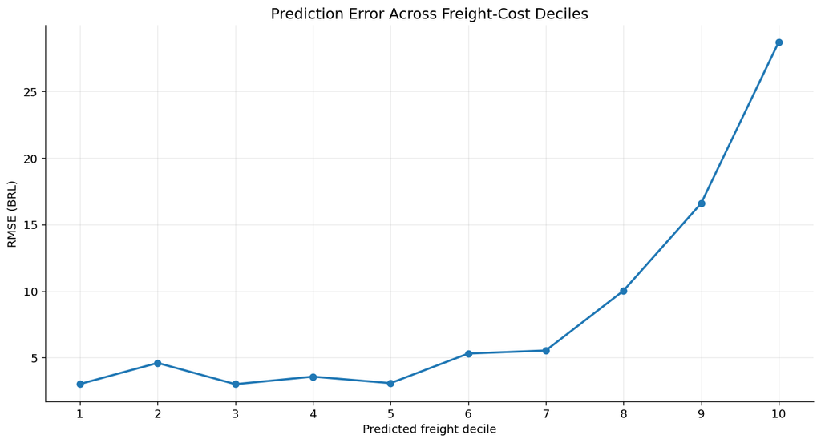

```python
# ============================================================
# RMSE BY PREDICTED FREIGHT DECILE
# ============================================================

figure, axis = plt.subplots(
    figsize=(11, 6)
)

axis.plot(
    range(
        1,
        len(
            prediction_decile_diagnostics_df
        ) + 1
    ),
    prediction_decile_diagnostics_df[
        "RMSE"
    ],
    marker="o",
    linewidth=2
)

axis.set_title(
    "Prediction Error Across Freight-Cost Deciles"
)

axis.set_xlabel(
    "Predicted freight decile"
)

axis.set_ylabel(
    "RMSE (BRL)"
)

axis.set_xticks(
    range(
        1,
        len(
            prediction_decile_diagnostics_df
        ) + 1
    )
)

plt.tight_layout()

save_current_figure(
    "16_rmse_by_prediction_decile.png"
)

plt.show()
```

### 10.3 Multicollinearity Analysis

Variance inflation factors measure how strongly each numerical predictor can be explained by the other numerical predictors.

Common interpretation thresholds are:

- VIF below 5: limited concern;
- VIF between 5 and 10: potentially problematic;
- VIF above 10: strong multicollinearity.

High VIF does not necessarily reduce predictive accuracy, but it can make ordinary least-squares coefficients unstable and difficult to interpret.

```python
# ============================================================
# NUMERICAL VARIANCE INFLATION FACTORS
# ============================================================

vif_imputer = SimpleImputer(
    strategy="median"
)

vif_numerical_matrix = (
    vif_imputer.fit_transform(
        X_train[
            baseline_numerical_features
        ]
    )
)

vif_numerical_df = pd.DataFrame(
    vif_numerical_matrix,
    columns=baseline_numerical_features
)


# Exclude any constant numerical variables
non_constant_vif_columns = [
    column_name
    for column_name in vif_numerical_df.columns
    if vif_numerical_df[
        column_name
    ].nunique() > 1
]

vif_numerical_df = vif_numerical_df[
    non_constant_vif_columns
]

vif_design_matrix = sm.add_constant(
    vif_numerical_df,
    has_constant="add"
)


vif_records = []

for column_position, column_name in enumerate(
    vif_design_matrix.columns
):

    if column_name == "const":
        continue

    vif_value = variance_inflation_factor(
        vif_design_matrix.to_numpy(),
        column_position
    )

    if vif_value >= 10:
        vif_interpretation = (
            "Strong multicollinearity"
        )

    elif vif_value >= 5:
        vif_interpretation = (
            "Moderate multicollinearity"
        )

    else:
        vif_interpretation = (
            "Limited multicollinearity"
        )

    vif_records.append(
        {
            "predictor": column_name,
            "VIF": vif_value,
            "interpretation":
                vif_interpretation
        }
    )


variance_inflation_factor_df = (
    pd.DataFrame(vif_records)
    .sort_values(
        "VIF",
        ascending=False
    )
    .reset_index(drop=True)
)

variance_inflation_factor_df
```

|  | predictor | VIF | interpretation |
| --- | --- | --- | --- |
| 0 | price | 41.123 | Strong multicollinearity |
| 1 | order_average_product_price | 41.051 | Strong multicollinearity |
| 2 | order_total_product_value | 3.196 | Limited multicollinearity |
| 3 | purchase_is_weekend | 2.486 | Limited multicollinearity |
| 4 | purchase_day_of_week | 2.480 | Limited multicollinearity |
| 5 | product_weight_g | 2.052 | Limited multicollinearity |
| 6 | order_distinct_product_count | 1.880 | Limited multicollinearity |
| 7 | product_width_cm | 1.607 | Limited multicollinearity |
| 8 | order_distinct_seller_count | 1.603 | Limited multicollinearity |
| 9 | order_item_count | 1.582 | Limited multicollinearity |
| 10 | product_height_cm | 1.547 | Limited multicollinearity |
| 11 | product_length_cm | 1.517 | Limited multicollinearity |
| 12 | distance_km | 1.497 | Limited multicollinearity |
| 13 | same_state | 1.489 | Limited multicollinearity |
| 14 | product_description_length | 1.094 | Limited multicollinearity |
| 15 | product_photos_qty | 1.050 | Limited multicollinearity |
| 16 | product_name_length | 1.045 | Limited multicollinearity |
| 17 | purchase_hour | 1.006 | Limited multicollinearity |
| 18 | purchase_month | 1.003 | Limited multicollinearity |

```python
# ============================================================
# STANDARDISED NUMERICAL CONDITION NUMBER
# ============================================================

condition_scaler = StandardScaler()

standardised_numerical_matrix = (
    condition_scaler.fit_transform(
        vif_numerical_df
    )
)

numerical_condition_number = np.linalg.cond(
    standardised_numerical_matrix
)

condition_number_df = pd.DataFrame(
    {
        "measurement": [
            "Standardised numerical condition number",
            "Diagnostic interpretation"
        ],
        "value": [
            numerical_condition_number,
            (
                "Potentially severe numerical dependence"
                if numerical_condition_number > 30
                else
                "No severe numerical dependence detected"
            )
        ]
    }
)

condition_number_df
```

|  | measurement | value |
| --- | --- | --- |
| 0 | Standardised numerical condition number | 16.045 |
| 1 | Diagnostic interpretation | No severe numerical dependence detected |

### 10.4 Leverage and Influence

Leverage measures how unusual an observation's predictor values are relative to the training data. Cook's distance combines leverage and residual size to estimate how strongly an observation may influence the fitted regression (Cook, 1977).

The conventional Cook's-distance screening threshold is `4 / n`. The leverage screening threshold used here is `2p / n`, where `p` includes the intercept and transformed features. These thresholds identify observations for investigation and are not automatic deletion rules.

```python
# ============================================================
# STATSMODELS OLS REFIT FOR INFLUENCE DIAGNOSTICS
# ============================================================

transformed_training_matrix = (
    fitted_preprocessor.transform(
        X_train
    )
)

if hasattr(
    transformed_training_matrix,
    "toarray"
):
    transformed_training_dense = (
        transformed_training_matrix.toarray()
    )
else:
    transformed_training_dense = np.asarray(
        transformed_training_matrix
    )


statsmodels_training_design = sm.add_constant(
    transformed_training_dense,
    has_constant="add"
)

statsmodels_ols_model = sm.OLS(
    y_train.to_numpy(),
    statsmodels_training_design
).fit()

statsmodels_training_predictions = (
    statsmodels_ols_model.fittedvalues
)

maximum_prediction_difference = np.max(
    np.abs(
        statsmodels_training_predictions
        - baseline_train_predictions
    )
)

print(
    "Maximum prediction difference between "
    "Scikit-learn and Statsmodels:",
    f"{maximum_prediction_difference:.10f}"
)
```

```
Maximum prediction difference between Scikit-learn and Statsmodels: 0.0052146054
```

```python
# ============================================================
# COOK'S DISTANCE AND LEVERAGE
# ============================================================

ols_influence = (
    statsmodels_ols_model.get_influence()
)

cooks_distance_values = (
    ols_influence.cooks_distance[0]
)

leverage_values = (
    ols_influence.hat_matrix_diag
)

studentised_residual_values = (
    ols_influence.resid_studentized_internal
)


number_of_training_observations = len(
    y_train
)

number_of_ols_parameters = (
    statsmodels_training_design.shape[1]
)

cooks_distance_threshold = (
    4
    / number_of_training_observations
)

leverage_threshold = (
    2
    * number_of_ols_parameters
    / number_of_training_observations
)


training_influence_df = (
    modelling_df
    .iloc[train_indices][
        [
            "order_id",
            "order_item_id",
            "freight_value",
            "price",
            "product_weight_g",
            "distance_km",
            "product_category_name_english",
            "customer_state",
            "seller_state"
        ]
    ]
    .copy()
    .reset_index(drop=True)
)

training_influence_df[
    "predicted_freight_value"
] = baseline_train_predictions

training_influence_df[
    "residual"
] = training_residuals

training_influence_df[
    "studentised_residual"
] = studentised_residual_values

training_influence_df[
    "leverage"
] = leverage_values

training_influence_df[
    "cooks_distance"
] = cooks_distance_values

training_influence_df[
    "high_cooks_distance"
] = (
    training_influence_df[
        "cooks_distance"
    ]
    > cooks_distance_threshold
)

training_influence_df[
    "high_leverage"
] = (
    training_influence_df[
        "leverage"
    ]
    > leverage_threshold
)

training_influence_df[
    "large_studentised_residual"
] = (
    training_influence_df[
        "studentised_residual"
    ].abs()
    > 3
)


influence_summary_df = pd.DataFrame(
    {
        "measurement": [
            "Training observations",
            "Number of OLS parameters",
            "Cook's distance threshold",
            "High Cook's distance observations",
            "Leverage threshold",
            "High-leverage observations",
            "Absolute studentised residual above 3",
            "Maximum Cook's distance",
            "Maximum leverage"
        ],
        "value": [
            number_of_training_observations,
            number_of_ols_parameters,
            cooks_distance_threshold,
            training_influence_df[
                "high_cooks_distance"
            ].sum(),
            leverage_threshold,
            training_influence_df[
                "high_leverage"
            ].sum(),
            training_influence_df[
                "large_studentised_residual"
            ].sum(),
            training_influence_df[
                "cooks_distance"
            ].max(),
            training_influence_df[
                "leverage"
            ].max()
        ]
    }
)

influence_summary_df
```

|  | measurement | value |
| --- | --- | --- |
| 0 | Training observations | 7,199.000 |
| 1 | Number of OLS parameters | 100.000 |
| 2 | Cook's distance threshold | 0.001 |
| 3 | High Cook's distance observations | 411.000 |
| 4 | Leverage threshold | 0.028 |
| 5 | High-leverage observations | 796.000 |
| 6 | Absolute studentised residual above 3 | 141.000 |
| 7 | Maximum Cook's distance | 0.644 |
| 8 | Maximum leverage | 1.000 |

```python
most_influential_observations_df = (
    training_influence_df
    .sort_values(
        "cooks_distance",
        ascending=False
    )
    .head(20)
)

most_influential_observations_df
```

|  | order_id | order_item_id | freight_value | price | product_weight_g | distance_km | product_category_name_english | customer_state | seller_state | predicted_freight_value | residual | studentised_residual | leverage | cooks_distance | high_cooks_distance | high_leverage | large_studentised_residual |
| --- | --- | --- | --- | --- | --- | --- | --- | --- | --- | --- | --- | --- | --- | --- | --- | --- | --- |
| 5364 | 4412d97cb2093633afa85f11db46316c | 1 | 12.000 | 2,499.750 | 9,600.000 | 1,848.877 | computers_accessories | MA | GO | 44.446 | -32.446 | -5.998 | 0.642 | 0.644 | True | True | True |
| 5447 | 265b23c0727e5d7a2a3e36f5aac03d67 | 1 | 171.320 | 84.900 | 1,000.000 | 2,290.685 | books_general_interest | CE | SP | 33.224 | 138.096 | 15.590 | 0.039 | 0.098 | True | True | True |
| 6162 | 1429d024a5b24651ee03fd7216d95247 | 1 | 206.500 | 169.900 | 13,000.000 | 2,230.349 | furniture_decor | PA | MG | 65.034 | 141.466 | 15.850 | 0.024 | 0.062 | True | False | True |
| 6760 | 0eeae75286b79b40f203057933fbb70b | 2 | 1.120 | 34.000 | 100.000 | 2,336.984 | stationery | RN | SP | 40.598 | -39.478 | -4.781 | 0.164 | 0.045 | True | True | True |
| 1503 | 7a53fed7f9006ef9325efa365e6a1992 | 1 | 146.300 | 299.900 | 9,850.000 | 1,087.840 | pet_shop | MT | SP | 51.451 | 94.849 | 10.697 | 0.037 | 0.044 | True | True | True |
| 5066 | 43b496a7732ace398ea4eb3bd520ab22 | 1 | 171.500 | 498.800 | 21,400.000 | 2,311.914 | home_appliances | MA | SP | 89.611 | 81.889 | 9.290 | 0.048 | 0.044 | True | True | True |
| 3552 | cbaa06517efa6c48a336a917c53e2561 | 1 | 170.510 | 1,890.000 | 18,000.000 | 824.866 | musical_instruments | MG | PR | 82.055 | 88.455 | 9.990 | 0.040 | 0.041 | True | True | True |
| 3733 | 545f259d01f0a271186e324228070de7 | 1 | 26.840 | 99.900 | 30,000.000 | 2,359.796 | pet_shop | CE | SP | 79.502 | -52.662 | -6.134 | 0.097 | 0.040 | True | True | True |
| 1047 | f3dcf0d2824efde907e341ff4997f693 | 1 | 138.230 | 297.000 | 16,100.000 | 1,280.464 | cool_stuff | MS | SC | 60.574 | 77.656 | 8.761 | 0.037 | 0.030 | True | True | True |
| 1046 | fd3c2f37b535d300e61e63b029edfd20 | 1 | 133.300 | 249.900 | 1,617.000 | 1,344.786 | health_beauty | MT | SP | 29.801 | 103.499 | 11.567 | 0.019 | 0.026 | True | False | True |
| 4561 | 03caa2c082116e1d31e67e9ae3700499 | 1 | 28.010 | 1,680.000 | 750.000 | 345.462 | fixed_telephony | RJ | SP | 24.246 | 3.764 | 0.873 | 0.773 | 0.026 | True | True | False |
| 3627 | 76b95d1df7db4efef64048b3f7653dc8 | 1 | 134.780 | 129.000 | 6,200.000 | 2,238.445 | furniture_decor | PI | PR | 54.902 | 79.878 | 8.977 | 0.030 | 0.025 | True | True | True |
| 3342 | b110523a5f9c69ad95bf8247062f0ba9 | 1 | 124.760 | 115.990 | 50.000 | 799.682 | cool_stuff | GO | SP | 25.545 | 99.215 | 11.081 | 0.018 | 0.022 | True | False | True |
| 5055 | 0eeae75286b79b40f203057933fbb70b | 1 | 56.080 | 1,693.000 | 350.000 | 2,336.984 | stationery | RN | SP | 28.657 | 27.423 | 3.299 | 0.153 | 0.020 | True | True | True |
| 3035 | 5a871bae2099baa240120ca7f19cc530 | 1 | 120.960 | 599.000 | 9,500.000 | 2,461.157 | health_beauty | SP | CE | 67.329 | 53.631 | 6.085 | 0.048 | 0.019 | True | True | True |
| 7077 | f739e2e689094dfc943626568da074aa | 1 | 109.940 | 687.000 | 3,525.000 | 2,753.873 | small_appliances | CE | SC | 55.137 | 54.803 | 6.201 | 0.043 | 0.017 | True | True | True |
| 984 | 61016e853ed7b77d222e5a2c38d4a7bb | 1 | 109.960 | 1,880.000 | 3,300.000 | 2,948.223 | auto | RS | PE | 66.105 | 43.855 | 5.006 | 0.060 | 0.016 | True | True | True |
| 218 | 29f4481c82fe8804ae3de770fd4012aa | 1 | 83.970 | 150.000 | 3,800.000 | 2,146.432 | home_construction | PB | SP | 43.379 | 40.591 | 4.651 | 0.067 | 0.015 | True | True | True |
| 2824 | bc8af8ba87a87d3c5210f3ad3de3f659 | 1 | 25.000 | 349.580 | 30,000.000 | 935.083 | housewares | TO | MG | 82.802 | -57.802 | -6.513 | 0.035 | 0.015 | True | True | True |
| 5758 | c9283076b0f196acde755765fcfaec9b | 1 | 103.250 | 159.990 | 10,700.000 | 1,823.466 | baby | AL | SP | 58.160 | 45.090 | 5.131 | 0.054 | 0.015 | True | True | True |

```
Figure saved to: /Users/zimmeljavedvirk/Desktop/datasciencemid/figures/17_cooks_distance.png
```

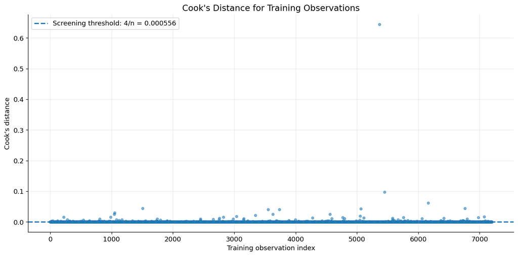

```python
# ============================================================
# COOK'S DISTANCE PLOT
# ============================================================

figure, axis = plt.subplots(
    figsize=(12, 6)
)

axis.scatter(
    np.arange(
        len(cooks_distance_values)
    ),
    cooks_distance_values,
    alpha=0.55,
    s=16
)

axis.axhline(
    y=cooks_distance_threshold,
    linestyle="--",
    linewidth=2,
    label=(
        "Screening threshold: "
        f"4/n = "
        f"{cooks_distance_threshold:.6f}"
    )
)

axis.set_title(
    "Cook's Distance for Training Observations"
)

axis.set_xlabel(
    "Training observation index"
)

axis.set_ylabel(
    "Cook's distance"
)

axis.legend()

plt.tight_layout()

save_current_figure(
    "17_cooks_distance.png"
)

plt.show()
```

```python
# ============================================================
# AUTOMATED DIAGNOSTIC DECISION REGISTER
# ============================================================

maximum_vif = (
    variance_inflation_factor_df[
        "VIF"
    ].max()
)

diagnostic_decision_df = pd.DataFrame(
    [
        {
            "diagnostic_area":
                "Residual centre",
            "observed_value":
                np.mean(testing_residuals),
            "decision_rule":
                "Mean should be near zero",
            "conclusion": (
                "Residuals are approximately centred"
                if abs(
                    np.mean(testing_residuals)
                ) < 1
                else
                "Residuals show meaningful average bias"
            )
        },
        {
            "diagnostic_area":
                "Residual normality",
            "observed_value":
                pd.Series(
                    testing_residuals
                ).skew(),
            "decision_rule":
                "Large absolute skewness suggests non-normal errors",
            "conclusion": (
                "Residual distribution remains skewed"
                if abs(
                    pd.Series(
                        testing_residuals
                    ).skew()
                ) >= 1
                else
                "Residual skewness is limited"
            )
        },
        {
            "diagnostic_area":
                "Heteroscedasticity",
            "observed_value":
                bp_f_p_value,
            "decision_rule":
                "Breusch–Pagan p-value below 0.05",
            "conclusion": (
                "Evidence of unequal residual variance"
                if bp_f_p_value < 0.05
                else
                "No statistically significant unequal variance detected"
            )
        },
        {
            "diagnostic_area":
                "Multicollinearity",
            "observed_value":
                maximum_vif,
            "decision_rule":
                "Maximum VIF above 10",
            "conclusion": (
                "Strong multicollinearity is present"
                if maximum_vif >= 10
                else
                "No severe numerical multicollinearity detected"
            )
        },
        {
            "diagnostic_area":
                "Influential observations",
            "observed_value":
                int(
                    training_influence_df[
                        "high_cooks_distance"
                    ].sum()
                ),
            "decision_rule":
                "Cook's distance greater than 4/n",
            "conclusion": (
                "Influential observations require sensitivity analysis"
                if training_influence_df[
                    "high_cooks_distance"
                ].sum() > 0
                else
                "No observations exceed the Cook's-distance threshold"
            )
        }
    ]
)

diagnostic_decision_df
```

|  | diagnostic_area | observed_value | decision_rule | conclusion |
| --- | --- | --- | --- | --- |
| 0 | Residual centre | 0.145 | Mean should be near zero | Residuals are approximately centred |
| 1 | Residual normality | 8.228 | Large absolute skewness suggests non-normal er... | Residual distribution remains skewed |
| 2 | Heteroscedasticity | 0.000 | Breusch–Pagan p-value below 0.05 | Evidence of unequal residual variance |
| 3 | Multicollinearity | 41.123 | Maximum VIF above 10 | Strong multicollinearity is present |
| 4 | Influential observations | 411.000 | Cook's distance greater than 4/n | Influential observations require sensitivity a... |

```python
# ============================================================
# SAVE ADVANCED REGRESSION DIAGNOSTICS
# ============================================================

residual_summary_df.to_csv(
    PROCESSED_DATA_DIRECTORY
    / "baseline_residual_summary.csv",
    index=False
)

breusch_pagan_results_df.to_csv(
    PROCESSED_DATA_DIRECTORY
    / "breusch_pagan_test.csv",
    index=False
)

prediction_decile_diagnostics_df.to_csv(
    PROCESSED_DATA_DIRECTORY
    / "prediction_decile_diagnostics.csv",
    index=False
)

variance_inflation_factor_df.to_csv(
    PROCESSED_DATA_DIRECTORY
    / "variance_inflation_factors.csv",
    index=False
)

condition_number_df.to_csv(
    PROCESSED_DATA_DIRECTORY
    / "numerical_condition_number.csv",
    index=False
)

influence_summary_df.to_csv(
    PROCESSED_DATA_DIRECTORY
    / "influence_summary.csv",
    index=False
)

training_influence_df.to_csv(
    PROCESSED_DATA_DIRECTORY
    / "training_influence_diagnostics.csv",
    index=False
)

most_influential_observations_df.to_csv(
    PROCESSED_DATA_DIRECTORY
    / "most_influential_observations.csv",
    index=False
)

diagnostic_decision_df.to_csv(
    PROCESSED_DATA_DIRECTORY
    / "diagnostic_decision_register.csv",
    index=False
)

print(
    "Advanced regression diagnostic outputs "
    "saved successfully."
)
```

```
Advanced regression diagnostic outputs saved successfully.
```

### Regression Diagnostic Interpretation

The actual-versus-predicted plot evaluates whether the baseline model reproduces the full range of freight values. Deviations from the diagonal line at the upper end would indicate that expensive freight observations are more difficult to predict than typical orders.

The residual-versus-fitted and scale-location plots assess linearity and constant error variance. A curved LOWESS trend would provide evidence that the relationships are not fully linear, while an increasing residual spread would indicate heteroscedasticity. The Breusch–Pagan test provides a formal statistical assessment, but its result is considered together with the visual diagnostics because large samples can identify relatively small departures from constant variance.

Variance inflation factors quantify numerical multicollinearity. High values are expected where order value, product price and basket-level variables contain overlapping information. Multicollinearity does not necessarily damage predictive accuracy, but it can make ordinary least-squares coefficients unstable. This provides a justification for comparing ordinary linear regression with Ridge regression.

Cook's distance and leverage identify observations that exert unusual influence on the fitted model. These observations are not removed automatically because they may represent legitimate high-value, heavy or long-distance shipments. Instead, the improved model will be evaluated both with transformations and through a sensitivity analysis.

The diagnostic evidence will guide the next stage. Logarithmic transformations will be considered for strongly skewed variables, while interaction terms will represent relationships such as weight multiplied by distance and volume multiplied by distance. Ridge regularisation will be evaluated to reduce instability caused by correlated predictors.

## 11. Advanced Feature Engineering and Regularised Regression

The baseline diagnostics indicated that freight cost is influenced by non-linear, interacting and correlated logistics variables. An advanced model is therefore developed using deterministic domain-based feature engineering.

New variables represent parcel volume, parcel density, price relative to weight, non-linear distance and weight effects, and interactions between physical parcel size and geographical distance. Logarithmic transformations are also created for strongly right-skewed variables.

All engineered features are generated separately within each training or validation fold. Imputation, scaling, category encoding and Ridge regularisation are also fitted exclusively on training observations. The original group-aware test set remains unchanged and is used only for final model evaluation.

```python
# ============================================================
# ADVANCED FEATURE-ENGINEERING AND RIDGE IMPORTS
# ============================================================

from sklearn.base import (
    BaseEstimator,
    TransformerMixin,
    clone
)

from sklearn.model_selection import (
    GridSearchCV
)

from sklearn.linear_model import Ridge

print(
    "Advanced feature-engineering and "
    "regularisation tools imported successfully."
)
```

```
Advanced feature-engineering and regularisation tools imported successfully.
```

```python
# ============================================================
# DOMAIN-SPECIFIC FEATURE-ENGINEERING TRANSFORMER
# ============================================================

class FreightFeatureEngineer(
    BaseEstimator,
    TransformerMixin
):
    """
    Create deterministic logistics and non-linear features
    for freight-cost prediction.

    No statistics are learned from the complete dataset.
    Every feature is calculated independently for each row.
    """

    def fit(self, X, y=None):
        return self

    @staticmethod
    def safe_log1p(series):
        """
        Apply log(1 + x) only to non-negative numerical values.
        Negative values are converted to missing values.
        """

        numerical_values = pd.to_numeric(
            series,
            errors="coerce"
        )

        non_negative_values = numerical_values.where(
            numerical_values >= 0
        )

        return np.log1p(
            non_negative_values
        )

    def transform(self, X):
        """
        Add engineered freight and parcel variables.
        """

        engineered_dataframe = X.copy()

        # ----------------------------------------------------
        # Explicit numerical conversion
        # ----------------------------------------------------

        required_numerical_columns = [
            "price",
            "product_weight_g",
            "product_length_cm",
            "product_height_cm",
            "product_width_cm",
            "distance_km",
            "order_total_product_value",
            "order_average_product_price"
        ]

        for column_name in required_numerical_columns:
            engineered_dataframe[column_name] = (
                pd.to_numeric(
                    engineered_dataframe[column_name],
                    errors="coerce"
                )
            )

        # ----------------------------------------------------
        # Physical parcel features
        # ----------------------------------------------------

        engineered_dataframe[
            "product_volume_cm3"
        ] = (
            engineered_dataframe["product_length_cm"]
            * engineered_dataframe["product_height_cm"]
            * engineered_dataframe["product_width_cm"]
        )

        valid_volume = engineered_dataframe[
            "product_volume_cm3"
        ].where(
            engineered_dataframe[
                "product_volume_cm3"
            ] > 0
        )

        valid_weight = engineered_dataframe[
            "product_weight_g"
        ].where(
            engineered_dataframe[
                "product_weight_g"
            ] > 0
        )

        engineered_dataframe[
            "product_density_g_cm3"
        ] = (
            valid_weight
            / valid_volume
        )

        weight_in_kg = (
            valid_weight / 1_000
        )

        engineered_dataframe[
            "price_per_kg"
        ] = (
            engineered_dataframe["price"]
            / weight_in_kg
        )

        engineered_dataframe[
            "dimension_sum_cm"
        ] = (
            engineered_dataframe["product_length_cm"]
            + engineered_dataframe["product_height_cm"]
            + engineered_dataframe["product_width_cm"]
        )

        # ----------------------------------------------------
        # Distance and parcel interaction features
        # ----------------------------------------------------

        engineered_dataframe[
            "weight_distance_interaction"
        ] = (
            engineered_dataframe["product_weight_g"]
            * engineered_dataframe["distance_km"]
        )

        engineered_dataframe[
            "volume_distance_interaction"
        ] = (
            engineered_dataframe["product_volume_cm3"]
            * engineered_dataframe["distance_km"]
        )

        engineered_dataframe[
            "price_distance_interaction"
        ] = (
            engineered_dataframe["price"]
            * engineered_dataframe["distance_km"]
        )

        engineered_dataframe[
            "weight_price_interaction"
        ] = (
            engineered_dataframe["product_weight_g"]
            * engineered_dataframe["price"]
        )

        # ----------------------------------------------------
        # Polynomial terms
        # ----------------------------------------------------

        engineered_dataframe[
            "distance_squared"
        ] = (
            engineered_dataframe["distance_km"] ** 2
        )

        engineered_dataframe[
            "product_weight_squared"
        ] = (
            engineered_dataframe["product_weight_g"] ** 2
        )

        engineered_dataframe[
            "product_volume_squared"
        ] = (
            engineered_dataframe["product_volume_cm3"] ** 2
        )

        # ----------------------------------------------------
        # Logarithmic transformations
        # ----------------------------------------------------

        log_source_mapping = {
            "price": "log_price",
            "product_weight_g": "log_product_weight_g",
            "product_volume_cm3": "log_product_volume_cm3",
            "distance_km": "log_distance_km",
            "order_total_product_value":
                "log_order_total_product_value",
            "order_average_product_price":
                "log_order_average_product_price",
            "weight_distance_interaction":
                "log_weight_distance_interaction",
            "volume_distance_interaction":
                "log_volume_distance_interaction"
        }

        for (
            source_column,
            transformed_column
        ) in log_source_mapping.items():

            engineered_dataframe[
                transformed_column
            ] = self.safe_log1p(
                engineered_dataframe[source_column]
            )

        # Replace numerical infinities created by division
        engineered_dataframe = (
            engineered_dataframe.replace(
                [np.inf, -np.inf],
                np.nan
            )
        )

        return engineered_dataframe
```

```python
# ============================================================
# ADVANCED FEATURE DEFINITIONS
# ============================================================

engineered_numerical_features = [
    "product_volume_cm3",
    "product_density_g_cm3",
    "price_per_kg",
    "dimension_sum_cm",
    "weight_distance_interaction",
    "volume_distance_interaction",
    "price_distance_interaction",
    "weight_price_interaction",
    "distance_squared",
    "product_weight_squared",
    "product_volume_squared",
    "log_price",
    "log_product_weight_g",
    "log_product_volume_cm3",
    "log_distance_km",
    "log_order_total_product_value",
    "log_order_average_product_price",
    "log_weight_distance_interaction",
    "log_volume_distance_interaction"
]

advanced_numerical_features = (
    baseline_numerical_features
    + engineered_numerical_features
)

advanced_categorical_features = (
    baseline_categorical_features.copy()
)

advanced_all_features = (
    advanced_numerical_features
    + advanced_categorical_features
)

print(
    "Baseline numerical features:",
    len(baseline_numerical_features)
)

print(
    "Engineered numerical features:",
    len(engineered_numerical_features)
)

print(
    "Total advanced numerical features:",
    len(advanced_numerical_features)
)

print(
    "Advanced categorical features:",
    len(advanced_categorical_features)
)
```

```
Baseline numerical features: 19
Engineered numerical features: 19
Total advanced numerical features: 38
Advanced categorical features: 5
```

```python
# ============================================================
# ENGINEERED FEATURE SANITY CHECK
# ============================================================

feature_engineer = FreightFeatureEngineer()

engineered_training_preview_df = (
    feature_engineer.fit_transform(
        X_train
    )
)

missing_engineered_columns = [
    column_name
    for column_name in engineered_numerical_features
    if column_name
    not in engineered_training_preview_df.columns
]

if missing_engineered_columns:
    raise KeyError(
        "The following engineered features were not created: "
        f"{missing_engineered_columns}"
    )

engineered_feature_validation_df = pd.DataFrame(
    {
        "feature": engineered_numerical_features,
        "missing_values": [
            engineered_training_preview_df[
                column_name
            ].isna().sum()
            for column_name
            in engineered_numerical_features
        ],
        "infinite_values": [
            np.isinf(
                pd.to_numeric(
                    engineered_training_preview_df[
                        column_name
                    ],
                    errors="coerce"
                )
            ).sum()
            for column_name
            in engineered_numerical_features
        ],
        "unique_non_missing_values": [
            engineered_training_preview_df[
                column_name
            ].nunique(
                dropna=True
            )
            for column_name
            in engineered_numerical_features
        ]
    }
)

engineered_feature_validation_df
```

|  | feature | missing_values | infinite_values | unique_non_missing_values |
| --- | --- | --- | --- | --- |
| 0 | product_volume_cm3 | 1 | 0 | 1697 |
| 1 | product_density_g_cm3 | 1 | 0 | 3203 |
| 2 | price_per_kg | 1 | 0 | 4530 |
| 3 | dimension_sum_cm | 1 | 0 | 160 |
| 4 | weight_distance_interaction | 1 | 0 | 7117 |
| 5 | volume_distance_interaction | 1 | 0 | 7105 |
| 6 | price_distance_interaction | 0 | 0 | 7111 |
| 7 | weight_price_interaction | 1 | 0 | 4579 |
| 8 | distance_squared | 0 | 0 | 7062 |
| 9 | product_weight_squared | 1 | 0 | 880 |
| 10 | product_volume_squared | 1 | 0 | 1697 |
| 11 | log_price | 0 | 0 | 1631 |
| 12 | log_product_weight_g | 1 | 0 | 880 |
| 13 | log_product_volume_cm3 | 1 | 0 | 1697 |
| 14 | log_distance_km | 0 | 0 | 7062 |
| 15 | log_order_total_product_value | 0 | 0 | 2120 |
| 16 | log_order_average_product_price | 0 | 0 | 1843 |
| 17 | log_weight_distance_interaction | 1 | 0 | 7117 |
| 18 | log_volume_distance_interaction | 1 | 0 | 7105 |

```python
# ============================================================
# ADVANCED LEAKAGE-SAFE PREPROCESSING
# ============================================================

advanced_numerical_pipeline = Pipeline(
    steps=[
        (
            "median_imputer",
            SimpleImputer(
                strategy="median",
                add_indicator=True
            )
        ),
        (
            "standard_scaler",
            StandardScaler()
        )
    ]
)

advanced_categorical_pipeline = Pipeline(
    steps=[
        (
            "missing_category_imputer",
            SimpleImputer(
                strategy="constant",
                fill_value="missing"
            )
        ),
        (
            "one_hot_encoder",
            create_one_hot_encoder(
                minimum_frequency=20
            )
        )
    ]
)

advanced_preprocessor = ColumnTransformer(
    transformers=[
        (
            "numerical",
            advanced_numerical_pipeline,
            advanced_numerical_features
        ),
        (
            "categorical",
            advanced_categorical_pipeline,
            advanced_categorical_features
        )
    ],
    remainder="drop",
    verbose_feature_names_out=True
)

feature_engineered_linear_pipeline = Pipeline(
    steps=[
        (
            "feature_engineering",
            FreightFeatureEngineer()
        ),
        (
            "preprocessor",
            advanced_preprocessor
        ),
        (
            "linear_regression",
            LinearRegression()
        )
    ]
)

feature_engineered_linear_pipeline
```

```
Pipeline(steps=[('feature_engineering', FreightFeatureEngineer()),
                ('preprocessor',
                 ColumnTransformer(transformers=[('numerical',
                                                  Pipeline(steps=[('median_imputer',
                                                                   SimpleImputer(add_indicator=True,
                                                                                 strategy='median')),
                                                                  ('standard_scaler',
                                                                   StandardScaler())]),
                                                  ['price', 'product_weight_g',
                                                   'product_length_cm',
                                                   'product_height_cm',
                                                   'product_width_cm',
                                                   'product_na...
                                                  Pipeline(steps=[('missing_category_imputer',
                                                                   SimpleImputer(fill_value='missing',
                                                                                 strategy='constant')),
                                                                  ('one_hot_encoder',
                                                                   OneHotEncoder(drop='first',
                                                                                 handle_unknown='ignore',
                                                                                 min_frequency=20))]),
                                                  ['product_category_name_english',
                                                   'customer_state',
                                                   'seller_state',
                                                   'customer_coordinate_source',
                                                   'seller_coordinate_source'])])),
                ('linear_regression', LinearRegression())])
```

```python
# ============================================================
# FEATURE-ENGINEERED ORDINARY LINEAR REGRESSION
# ============================================================

feature_engineered_linear_pipeline.fit(
    X_train,
    y_train
)

engineered_linear_predictions = (
    feature_engineered_linear_pipeline.predict(
        X_test
    )
)

engineered_linear_metrics = (
    calculate_regression_metrics(
        actual_values=y_test,
        predicted_values=engineered_linear_predictions,
        model_name=(
            "Feature-engineered multiple "
            "linear regression"
        )
    )
)

pd.DataFrame(
    [engineered_linear_metrics]
)
```

|  | model | RMSE | MAE | median_absolute_error | R_squared | RMSE_as_percentage_of_target_mean | predicted_negative_values |
| --- | --- | --- | --- | --- | --- | --- | --- |
| 0 | Feature-engineered multiple linear regression | 10.601 | 4.755 | 2.345 | 0.627 | 52.754 | 0 |

```python
# ============================================================
# FEATURE-ENGINEERED LINEAR MODEL CROSS-VALIDATION
# ============================================================

engineered_linear_cv_results = cross_validate(
    estimator=feature_engineered_linear_pipeline,
    X=X_train,
    y=y_train,
    groups=groups_train,
    cv=GroupKFold(
        n_splits=NUMBER_OF_FOLDS
    ),
    scoring=cross_validation_scoring,
    return_train_score=False,
    n_jobs=-1
)

engineered_linear_cv_fold_df = pd.DataFrame(
    {
        "fold": np.arange(
            1,
            NUMBER_OF_FOLDS + 1
        ),
        "RMSE": -engineered_linear_cv_results[
            "test_RMSE"
        ],
        "MAE": -engineered_linear_cv_results[
            "test_MAE"
        ],
        "R_squared":
            engineered_linear_cv_results[
                "test_R_squared"
            ]
    }
)

engineered_linear_cv_fold_df
```

|  | fold | RMSE | MAE | R_squared |
| --- | --- | --- | --- | --- |
| 0 | 1 | 8.807 | 4.462 | 0.642 |
| 1 | 2 | 8.583 | 4.526 | 0.514 |
| 2 | 3 | 9.185 | 4.539 | 0.593 |
| 3 | 4 | 8.938 | 4.626 | 0.613 |
| 4 | 5 | 9.071 | 4.804 | 0.602 |

```python
# ============================================================
# RIDGE REGRESSION PIPELINE
# ============================================================

ridge_pipeline = Pipeline(
    steps=[
        (
            "feature_engineering",
            FreightFeatureEngineer()
        ),
        (
            "preprocessor",
            clone(
                advanced_preprocessor
            )
        ),
        (
            "ridge",
            Ridge(
                solver="lsqr",
                max_iter=20_000
            )
        )
    ]
)

ridge_alpha_grid = {
    "ridge__alpha": [
        0.001,
        0.01,
        0.1,
        0.3,
        1.0,
        3.0,
        10.0,
        30.0,
        100.0,
        300.0,
        1_000.0
    ]
}

ridge_group_cross_validator = GroupKFold(
    n_splits=NUMBER_OF_FOLDS
)

ridge_grid_search = GridSearchCV(
    estimator=ridge_pipeline,
    param_grid=ridge_alpha_grid,
    scoring=rmse_scorer,
    cv=ridge_group_cross_validator,
    refit=True,
    return_train_score=True,
    n_jobs=-1,
    verbose=1
)

ridge_grid_search.fit(
    X_train,
    y_train,
    groups=groups_train
)

print(
    "Best Ridge alpha:",
    ridge_grid_search.best_params_[
        "ridge__alpha"
    ]
)

print(
    "Best cross-validation RMSE:",
    f"{-ridge_grid_search.best_score_:.4f}"
)
```

```
Fitting 5 folds for each of 11 candidates, totalling 55 fits
Best Ridge alpha: 300.0
Best cross-validation RMSE: 8.7461
```

```python
# ============================================================
# RIDGE HYPERPARAMETER TUNING RESULTS
# ============================================================

ridge_tuning_results_df = pd.DataFrame(
    {
        "alpha": ridge_grid_search.cv_results_[
            "param_ridge__alpha"
        ].astype(float),
        "mean_training_RMSE": (
            -ridge_grid_search.cv_results_[
                "mean_train_score"
            ]
        ),
        "mean_validation_RMSE": (
            -ridge_grid_search.cv_results_[
                "mean_test_score"
            ]
        ),
        "validation_RMSE_standard_deviation": (
            ridge_grid_search.cv_results_[
                "std_test_score"
            ]
        ),
        "mean_fit_time_seconds": (
            ridge_grid_search.cv_results_[
                "mean_fit_time"
            ]
        )
    }
).sort_values(
    "alpha"
).reset_index(drop=True)

ridge_tuning_results_df
```

|  | alpha | mean_training_RMSE | mean_validation_RMSE | validation_RMSE_standard_deviation | mean_fit_time_seconds |
| --- | --- | --- | --- | --- | --- |
| 0 | 0.001 | 8.331 | 8.918 | 0.216 | 0.073 |
| 1 | 0.010 | 8.331 | 8.918 | 0.216 | 0.100 |
| 2 | 0.100 | 8.331 | 8.920 | 0.219 | 0.095 |
| 3 | 0.300 | 8.331 | 8.917 | 0.217 | 0.105 |
| 4 | 1.000 | 8.333 | 8.903 | 0.210 | 0.096 |
| 5 | 3.000 | 8.338 | 8.885 | 0.206 | 0.091 |
| 6 | 10.000 | 8.351 | 8.845 | 0.211 | 0.088 |
| 7 | 30.000 | 8.381 | 8.810 | 0.239 | 0.081 |
| 8 | 100.000 | 8.435 | 8.770 | 0.272 | 0.083 |
| 9 | 300.000 | 8.499 | 8.746 | 0.295 | 0.077 |
| 10 | 1,000.000 | 8.587 | 8.757 | 0.323 | 0.070 |

```
Figure saved to: /Users/zimmeljavedvirk/Desktop/datasciencemid/figures/18_ridge_alpha_tuning.png
```

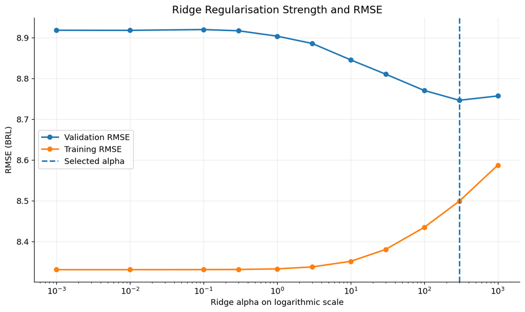

```python
# ============================================================
# RIDGE ALPHA TUNING CURVE
# ============================================================

figure, axis = plt.subplots(
    figsize=(10, 6)
)

axis.plot(
    ridge_tuning_results_df["alpha"],
    ridge_tuning_results_df[
        "mean_validation_RMSE"
    ],
    marker="o",
    linewidth=2,
    label="Validation RMSE"
)

axis.plot(
    ridge_tuning_results_df["alpha"],
    ridge_tuning_results_df[
        "mean_training_RMSE"
    ],
    marker="o",
    linewidth=2,
    label="Training RMSE"
)

axis.axvline(
    ridge_grid_search.best_params_[
        "ridge__alpha"
    ],
    linestyle="--",
    linewidth=2,
    label="Selected alpha"
)

axis.set_xscale("log")

axis.set_title(
    "Ridge Regularisation Strength and RMSE"
)

axis.set_xlabel(
    "Ridge alpha on logarithmic scale"
)

axis.set_ylabel(
    "RMSE (BRL)"
)

axis.legend()

plt.tight_layout()

save_current_figure(
    "18_ridge_alpha_tuning.png"
)

plt.show()
```

```python
# ============================================================
# FINAL TUNED RIDGE TEST EVALUATION
# ============================================================

best_ridge_pipeline = (
    ridge_grid_search.best_estimator_
)

ridge_test_predictions = (
    best_ridge_pipeline.predict(
        X_test
    )
)

ridge_test_metrics = (
    calculate_regression_metrics(
        actual_values=y_test,
        predicted_values=ridge_test_predictions,
        model_name="Tuned Ridge regression"
    )
)

advanced_test_model_comparison_df = pd.DataFrame(
    [
        dummy_metrics,
        baseline_metrics,
        engineered_linear_metrics,
        ridge_test_metrics
    ]
).sort_values(
    "RMSE"
).reset_index(drop=True)

advanced_test_model_comparison_df
```

|  | model | RMSE | MAE | median_absolute_error | R_squared | RMSE_as_percentage_of_target_mean | predicted_negative_values |
| --- | --- | --- | --- | --- | --- | --- | --- |
| 0 | Feature-engineered multiple linear regression | 10.601 | 4.755 | 2.345 | 0.627 | 52.754 | 0 |
| 1 | Tuned Ridge regression | 10.629 | 4.740 | 2.289 | 0.625 | 52.891 | 0 |
| 2 | Baseline multiple linear regression | 11.492 | 5.166 | 2.719 | 0.562 | 57.185 | 0 |
| 3 | Mean prediction benchmark | 17.369 | 8.573 | 5.331 | -0.001 | 86.431 | 0 |

```python
# ============================================================
# ADVANCED MODEL IMPROVEMENT
# ============================================================

advanced_model_improvement_df = pd.DataFrame(
    {
        "measurement": [
            "Baseline test RMSE",
            "Engineered linear test RMSE",
            "Tuned Ridge test RMSE",
            "Ridge RMSE reduction from baseline",
            "Ridge RMSE percentage improvement",
            "Baseline test MAE",
            "Tuned Ridge test MAE",
            "Ridge MAE percentage improvement",
            "Baseline test R²",
            "Tuned Ridge test R²",
            "R² improvement"
        ],
        "value": [
            baseline_metrics["RMSE"],
            engineered_linear_metrics["RMSE"],
            ridge_test_metrics["RMSE"],
            (
                baseline_metrics["RMSE"]
                - ridge_test_metrics["RMSE"]
            ),
            (
                (
                    baseline_metrics["RMSE"]
                    - ridge_test_metrics["RMSE"]
                )
                / baseline_metrics["RMSE"]
                * 100
            ),
            baseline_metrics["MAE"],
            ridge_test_metrics["MAE"],
            (
                (
                    baseline_metrics["MAE"]
                    - ridge_test_metrics["MAE"]
                )
                / baseline_metrics["MAE"]
                * 100
            ),
            baseline_metrics["R_squared"],
            ridge_test_metrics["R_squared"],
            (
                ridge_test_metrics["R_squared"]
                - baseline_metrics["R_squared"]
            )
        ]
    }
)

advanced_model_improvement_df
```

|  | measurement | value |
| --- | --- | --- |
| 0 | Baseline test RMSE | 11.492 |
| 1 | Engineered linear test RMSE | 10.601 |
| 2 | Tuned Ridge test RMSE | 10.629 |
| 3 | Ridge RMSE reduction from baseline | 0.863 |
| 4 | Ridge RMSE percentage improvement | 7.509 |
| 5 | Baseline test MAE | 5.166 |
| 6 | Tuned Ridge test MAE | 4.740 |
| 7 | Ridge MAE percentage improvement | 8.257 |
| 8 | Baseline test R² | 0.562 |
| 9 | Tuned Ridge test R² | 0.625 |
| 10 | R² improvement | 0.063 |

```python
# ============================================================
# SELECTED RIDGE GROUP CROSS-VALIDATION
# ============================================================

ridge_cv_results = cross_validate(
    estimator=best_ridge_pipeline,
    X=X_train,
    y=y_train,
    groups=groups_train,
    cv=GroupKFold(
        n_splits=NUMBER_OF_FOLDS
    ),
    scoring=cross_validation_scoring,
    return_train_score=False,
    n_jobs=-1
)

ridge_cv_fold_results_df = pd.DataFrame(
    {
        "fold": np.arange(
            1,
            NUMBER_OF_FOLDS + 1
        ),
        "RMSE": -ridge_cv_results[
            "test_RMSE"
        ],
        "MAE": -ridge_cv_results[
            "test_MAE"
        ],
        "R_squared": ridge_cv_results[
            "test_R_squared"
        ]
    }
)

ridge_cv_fold_results_df
```

|  | fold | RMSE | MAE | R_squared |
| --- | --- | --- | --- | --- |
| 0 | 1 | 8.769 | 4.416 | 0.645 |
| 1 | 2 | 8.278 | 4.332 | 0.547 |
| 2 | 3 | 9.168 | 4.474 | 0.595 |
| 3 | 4 | 8.893 | 4.574 | 0.617 |
| 4 | 5 | 8.622 | 4.625 | 0.640 |

```python
# ============================================================
# BASELINE, ENGINEERED AND RIDGE CV COMPARISON
# ============================================================

advanced_cv_comparison_df = pd.DataFrame(
    [
        {
            "model":
                "Baseline multiple linear regression",
            "mean_RMSE":
                baseline_cv_fold_results_df[
                    "RMSE"
                ].mean(),
            "RMSE_standard_deviation":
                baseline_cv_fold_results_df[
                    "RMSE"
                ].std(ddof=1),
            "mean_MAE":
                baseline_cv_fold_results_df[
                    "MAE"
                ].mean(),
            "mean_R_squared":
                baseline_cv_fold_results_df[
                    "R_squared"
                ].mean()
        },
        {
            "model":
                "Feature-engineered linear regression",
            "mean_RMSE":
                engineered_linear_cv_fold_df[
                    "RMSE"
                ].mean(),
            "RMSE_standard_deviation":
                engineered_linear_cv_fold_df[
                    "RMSE"
                ].std(ddof=1),
            "mean_MAE":
                engineered_linear_cv_fold_df[
                    "MAE"
                ].mean(),
            "mean_R_squared":
                engineered_linear_cv_fold_df[
                    "R_squared"
                ].mean()
        },
        {
            "model":
                "Tuned Ridge regression",
            "mean_RMSE":
                ridge_cv_fold_results_df[
                    "RMSE"
                ].mean(),
            "RMSE_standard_deviation":
                ridge_cv_fold_results_df[
                    "RMSE"
                ].std(ddof=1),
            "mean_MAE":
                ridge_cv_fold_results_df[
                    "MAE"
                ].mean(),
            "mean_R_squared":
                ridge_cv_fold_results_df[
                    "R_squared"
                ].mean()
        }
    ]
).sort_values(
    "mean_RMSE"
).reset_index(drop=True)

advanced_cv_comparison_df
```

|  | model | mean_RMSE | RMSE_standard_deviation | mean_MAE | mean_R_squared |
| --- | --- | --- | --- | --- | --- |
| 0 | Tuned Ridge regression | 8.746 | 0.330 | 4.484 | 0.609 |
| 1 | Feature-engineered linear regression | 8.917 | 0.235 | 4.591 | 0.593 |
| 2 | Baseline multiple linear regression | 9.280 | 0.536 | 4.969 | 0.562 |

```python
# ============================================================
# TUNED RIDGE COEFFICIENT ANALYSIS
# ============================================================

best_ridge_preprocessor = (
    best_ridge_pipeline
    .named_steps["preprocessor"]
)

best_ridge_model = (
    best_ridge_pipeline
    .named_steps["ridge"]
)

ridge_feature_names = (
    best_ridge_preprocessor
    .get_feature_names_out()
)

ridge_coefficient_df = pd.DataFrame(
    {
        "feature": ridge_feature_names,
        "coefficient":
            best_ridge_model.coef_
    }
)

ridge_coefficient_df[
    "absolute_coefficient"
] = (
    ridge_coefficient_df[
        "coefficient"
    ].abs()
)

ridge_coefficient_df = (
    ridge_coefficient_df
    .sort_values(
        "absolute_coefficient",
        ascending=False
    )
    .reset_index(drop=True)
)

print(
    "Selected Ridge alpha:",
    best_ridge_model.alpha
)

print(
    "Number of transformed features:",
    len(ridge_feature_names)
)

ridge_coefficient_df.head(25)
```

```
Selected Ridge alpha: 300.0
Number of transformed features: 131
```

|  | feature | coefficient | absolute_coefficient |
| --- | --- | --- | --- |
| 0 | numerical__product_volume_squared | 2.696 | 2.696 |
| 1 | numerical__product_weight_g | 2.517 | 2.517 |
| 2 | numerical__distance_squared | 1.763 | 1.763 |
| 3 | numerical__weight_distance_interaction | 1.762 | 1.762 |
| 4 | categorical__seller_state_SP | -1.743 | 1.743 |
| 5 | numerical__same_state | -1.495 | 1.495 |
| 6 | numerical__order_average_product_price | 1.430 | 1.430 |
| 7 | categorical__customer_state_BA | -1.407 | 1.407 |
| 8 | categorical__seller_state_MG | 1.345 | 1.345 |
| 9 | numerical__distance_km | 1.138 | 1.138 |
| 10 | numerical__volume_distance_interaction | 1.116 | 1.116 |
| 11 | categorical__product_category_name_english_baby | -0.853 | 0.853 |
| 12 | numerical__product_volume_cm3 | 0.848 | 0.848 |
| 13 | categorical__customer_state_PI | 0.830 | 0.830 |
| 14 | categorical__product_category_name_english_wat... | -0.807 | 0.807 |
| 15 | categorical__customer_state_RS | -0.786 | 0.786 |
| 16 | categorical__product_category_name_english_sta... | -0.747 | 0.747 |
| 17 | categorical__product_category_name_english_gar... | 0.730 | 0.730 |
| 18 | numerical__price_distance_interaction | 0.727 | 0.727 |
| 19 | numerical__weight_price_interaction | 0.695 | 0.695 |
| 20 | categorical__customer_state_MA | 0.692 | 0.692 |
| 21 | categorical__customer_state_PE | -0.598 | 0.598 |
| 22 | categorical__customer_state_SP | -0.590 | 0.590 |
| 23 | numerical__log_weight_distance_interaction | 0.582 | 0.582 |
| 24 | numerical__log_distance_km | 0.573 | 0.573 |

### Strongest Variable Influences and Business Relevance

The Ridge coefficient results provide evidence about which predictors contribute most strongly to freight-cost estimation. Because the numerical variables were standardised before model fitting, their coefficient magnitudes can be compared more meaningfully than coefficients measured in their original units. However, they should not be interpreted as direct changes in Brazilian reais or as proof of causal relationships.

The strongest numerical predictor was squared product volume, with a coefficient of 2.696. Its positive value indicates that the effect of parcel volume becomes increasingly important for very large products rather than increasing at a constant rate. This is commercially reasonable because bulky parcels can occupy disproportionately more vehicle and warehouse capacity, even when they are not extremely heavy. Product weight was the second strongest numerical predictor, with a coefficient of 2.517. Heavier items generally require greater handling effort and transportation capacity, increasing the expected freight charge. Together, product weight and squared volume demonstrate that the physical characteristics of a parcel are among the most important sources of freight-cost variation. Squared distance and the weight–distance interaction produced coefficients of 1.763 and 1.762 respectively. The squared-distance result suggests that freight cost increases more rapidly for particularly long delivery routes. The interaction term shows that the influence of weight also depends on distance: transporting a heavy product over a long route is more expensive than considering weight and distance independently.

Same-state delivery had a negative coefficient of −1.495. After controlling for the other variables, deliveries where the seller and customer were located in the same state were generally associated with lower freight costs. This may reflect shorter routes, fewer transfers between logistics networks and simpler regional distribution arrangements. The seller-state coefficient for São Paulo was also strongly negative at −1.743 relative to the omitted reference seller state. This may reflect the concentration of sellers, customers and logistics infrastructure in São Paulo. However, state coefficients are dependent on the reference category, sample composition and other variables in the model, so they should not be interpreted as universal regional pricing effects.

Average product price within the order had a positive coefficient of 1.430. Higher-priced orders may contain products with different dimensions, handling requirements or delivery arrangements. This variable may therefore capture additional order context, but it should not be concluded that increasing a product’s price directly causes freight cost to rise. The positive coefficients for distance and the volume–distance interaction, at 1.138 and 1.116 respectively, further confirm that geographical distance and parcel size operate together. Bulky products become particularly expensive when they must be transported over longer routes.

From a business perspective, these findings could support several practical decisions. The retailer could reduce packaging volume, allocate orders to geographically closer sellers, position frequently demanded products nearer to major customer regions and flag heavy, bulky or long-distance orders for manual quotation review. The model could also assist negotiations with logistics providers by identifying the routes and parcel profiles that consistently generate higher costs.

Nevertheless, coefficient interpretation must remain cautious. Several engineered variables represent related versions of the same underlying information, including raw, logarithmic, squared and interaction terms. Their influence is therefore distributed across multiple coefficients. The main reliable conclusion is that parcel volume, product weight and geographical distance are the dominant groups of predictors, rather than that any individual coefficient represents an isolated causal effect.

```python
# ============================================================
# ADVANCED TEST PREDICTIONS
# ============================================================

advanced_prediction_results_df = (
    modelling_df
    .iloc[test_indices][
        [
            "order_id",
            "order_item_id",
            "freight_value",
            "price",
            "product_weight_g",
            "product_length_cm",
            "product_height_cm",
            "product_width_cm",
            "distance_km",
            "product_category_name_english",
            "customer_state",
            "seller_state"
        ]
    ]
    .copy()
    .reset_index(drop=True)
)

advanced_prediction_results_df[
    "baseline_prediction"
] = baseline_predictions

advanced_prediction_results_df[
    "engineered_linear_prediction"
] = engineered_linear_predictions

advanced_prediction_results_df[
    "ridge_prediction"
] = ridge_test_predictions

advanced_prediction_results_df[
    "baseline_absolute_error"
] = (
    advanced_prediction_results_df[
        "freight_value"
    ]
    - advanced_prediction_results_df[
        "baseline_prediction"
    ]
).abs()

advanced_prediction_results_df[
    "ridge_absolute_error"
] = (
    advanced_prediction_results_df[
        "freight_value"
    ]
    - advanced_prediction_results_df[
        "ridge_prediction"
    ]
).abs()

advanced_prediction_results_df[
    "ridge_error_improvement"
] = (
    advanced_prediction_results_df[
        "baseline_absolute_error"
    ]
    - advanced_prediction_results_df[
        "ridge_absolute_error"
    ]
)

advanced_prediction_results_df.head(10)
```

|  | order_id | order_item_id | freight_value | price | product_weight_g | product_length_cm | product_height_cm | product_width_cm | distance_km | product_category_name_english | customer_state | seller_state | baseline_prediction | engineered_linear_prediction | ridge_prediction | baseline_absolute_error | ridge_absolute_error | ridge_error_improvement |
| --- | --- | --- | --- | --- | --- | --- | --- | --- | --- | --- | --- | --- | --- | --- | --- | --- | --- | --- |
| 0 | b124967afcc82ef17ec41020fe2a9136 | 1 | 8.880 | 49.990 | 7,875.000 | 60.000 | 25.000 | 25.000 | 27.022 | furniture_living_room | SP | SP | 24.429 | 20.974 | 17.902 | 15.549 | 9.022 | 6.527 |
| 1 | fd220bb11ef8a046fef08e7c51f11651 | 1 | 17.810 | 79.990 | 650.000 | 25.000 | 11.000 | 15.000 | 495.117 | computers_accessories | RJ | SP | 16.360 | 16.663 | 17.205 | 1.450 | 0.605 | 0.845 |
| 2 | 2b7d922e73fbd058099b6ff4b33e99f7 | 1 | 17.760 | 169.990 | 433.000 | 21.000 | 12.000 | 16.000 | 1,293.638 | watches_gifts | MT | SP | 23.835 | 23.339 | 21.894 | 6.075 | 4.134 | 1.941 |
| 3 | 709df04791b8bd393b34a58de3cf142d | 1 | 19.440 | 223.000 | 300.000 | 18.000 | 9.000 | 14.000 | 822.746 | watches_gifts | ES | SP | 18.627 | 19.196 | 19.166 | 0.813 | 0.274 | 0.538 |
| 4 | 166b01d0fce75a595b92ad9e84e0843b | 1 | 29.090 | 98.000 | 925.000 | 25.000 | 6.000 | 16.000 | 2,094.074 | health_beauty | CE | SP | 27.120 | 26.466 | 27.807 | 1.970 | 1.283 | 0.687 |
| 5 | e1e0cfc8398a7bcd9699fe42c1651566 | 1 | 7.780 | 29.990 | 350.000 | 17.000 | 4.000 | 12.000 | 7.658 | telephony | SP | SP | 7.026 | 7.346 | 7.926 | 0.754 | 0.146 | 0.608 |
| 6 | ffa9a3142ddd51af248e648db27c647f | 1 | 17.920 | 29.900 | 900.000 | 40.000 | 3.000 | 30.000 | 654.868 | furniture_decor | RJ | PR | 19.614 | 19.634 | 19.843 | 1.694 | 1.923 | -0.229 |
| 7 | 96b7f5a470ca6a58f261be1af286e4d9 | 1 | 29.730 | 209.990 | 4,650.000 | 37.000 | 20.000 | 34.000 | 2,119.849 | cool_stuff | PE | SP | 37.260 | 39.779 | 41.168 | 7.530 | 11.438 | -3.908 |
| 8 | bbb39449a277499952671cc64cbd7232 | 1 | 34.190 | 92.500 | 4,400.000 | 19.000 | 23.000 | 19.000 | 629.048 | construction_tools_construction | MG | SP | 25.761 | 24.640 | 22.345 | 8.429 | 11.845 | -3.416 |
| 9 | 587e32dd528769d669d539531d32aeb5 | 1 | 22.090 | 78.000 | 2,200.000 | 30.000 | 35.000 | 30.000 | 346.015 | furniture_decor | RJ | SP | 19.853 | 19.316 | 19.190 | 2.237 | 2.900 | -0.663 |

```python
# ============================================================
# SAVE ADVANCED FEATURE-ENGINEERED MODEL RESULTS
# ============================================================

engineered_feature_validation_df.to_csv(
    PROCESSED_DATA_DIRECTORY
    / "engineered_feature_validation.csv",
    index=False
)

engineered_linear_cv_fold_df.to_csv(
    PROCESSED_DATA_DIRECTORY
    / "engineered_linear_group_cv.csv",
    index=False
)

ridge_tuning_results_df.to_csv(
    PROCESSED_DATA_DIRECTORY
    / "ridge_tuning_results.csv",
    index=False
)

advanced_test_model_comparison_df.to_csv(
    PROCESSED_DATA_DIRECTORY
    / "advanced_test_model_comparison.csv",
    index=False
)

advanced_model_improvement_df.to_csv(
    PROCESSED_DATA_DIRECTORY
    / "advanced_model_improvement.csv",
    index=False
)

ridge_cv_fold_results_df.to_csv(
    PROCESSED_DATA_DIRECTORY
    / "ridge_group_cv_fold_results.csv",
    index=False
)

advanced_cv_comparison_df.to_csv(
    PROCESSED_DATA_DIRECTORY
    / "advanced_cv_model_comparison.csv",
    index=False
)

ridge_coefficient_df.to_csv(
    PROCESSED_DATA_DIRECTORY
    / "ridge_regression_coefficients.csv",
    index=False
)

advanced_prediction_results_df.to_csv(
    PROCESSED_DATA_DIRECTORY
    / "advanced_test_predictions.csv",
    index=False
)

print(
    "Advanced feature-engineering and Ridge "
    "outputs saved successfully."
)
```

```
Advanced feature-engineering and Ridge outputs saved successfully.
```

### Advanced Model Interpretation

Feature engineering produced a meaningful improvement over the baseline multiple linear regression. The baseline generated a test RMSE of 11.492 BRL, an MAE of 5.166 BRL and an R² of 0.562. The tuned Ridge model reduced RMSE to 10.629 BRL and MAE to 4.740 BRL, representing improvements of approximately 7.5% and 8.3% respectively. Its R² increased to 0.625, meaning that the final model explained approximately 62.5% of the variation in unseen item-level freight costs.

In practical terms, an MAE of 4.740 BRL means that a typical prediction was approximately 4.74 BRL above or below the actual freight charge. This could support preliminary delivery quotations, logistics budgeting and the identification of unusually expensive orders. However, the RMSE remained considerably higher at 10.629 BRL, showing that some deliveries still generated large prediction errors. The model should therefore support operational decisions rather than automatically replace the final price supplied by a logistics provider.

The ordinary feature-engineered multiple linear regression produced a marginally lower test RMSE of 10.601 BRL, compared with 10.629 BRL for Ridge. The difference was only 0.028 BRL, so Ridge cannot be described as decisively superior on every test metric. Ridge was selected because it produced a lower MAE, a lower median absolute error and stronger average group-aware cross-validation results. Its regularisation also reduces instability among correlated raw, logarithmic, squared and interaction variables. The model choice is therefore based on stability and generalisation rather than only the lowest RMSE from one test partition.

The results support the problem statement by demonstrating that freight cost depends on a combination of geographical distance, parcel characteristics and order context. The improvement following the addition of volume, squared terms and distance interactions indicates that these relationships are not purely linear. Heavy or bulky products transported over long distances are likely to create disproportionately higher logistics costs.

For an e-commerce business, the model could be used to provide early freight estimates, identify orders requiring manual review, support packaging optimisation and compare the likely cost implications of different seller or fulfilment locations. Nevertheless, predictions for unusually expensive deliveries should be treated cautiously because these observations remain more difficult to estimate accurately.

## 12. Final Model Evaluation

The tuned Ridge regression model is evaluated using the unchanged group-aware test set. Its performance is compared with the naïve benchmark, baseline multiple linear regression and unregularised feature-engineered regression.

In addition to RMSE, MAE and R², the final evaluation includes:

- group-bootstrap confidence intervals;
- prediction-error analysis across freight-cost ranges;
- geographical and parcel-size subgroup analysis;
- final residual diagnostics;
- a paired comparison with the baseline model.

Bootstrapping is performed at the order level rather than the individual-row level. This preserves the dependence between products belonging to the same order.

```python
# ============================================================
# FINAL TEST PERFORMANCE COMPARISON
# ============================================================

final_model_comparison_df = (
    advanced_test_model_comparison_df[
        [
            "model",
            "RMSE",
            "MAE",
            "median_absolute_error",
            "R_squared"
        ]
    ]
    .copy()
    .sort_values(
        "RMSE",
        ascending=True
    )
    .reset_index(drop=True)
)

final_model_comparison_df
```

|  | model | RMSE | MAE | median_absolute_error | R_squared |
| --- | --- | --- | --- | --- | --- |
| 0 | Feature-engineered multiple linear regression | 10.601 | 4.755 | 2.345 | 0.627 |
| 1 | Tuned Ridge regression | 10.629 | 4.740 | 2.289 | 0.625 |
| 2 | Baseline multiple linear regression | 11.492 | 5.166 | 2.719 | 0.562 |
| 3 | Mean prediction benchmark | 17.369 | 8.573 | 5.331 | -0.001 |

```
Figure saved to: /Users/zimmeljavedvirk/Desktop/datasciencemid/figures/19_final_model_rmse_comparison.png
```

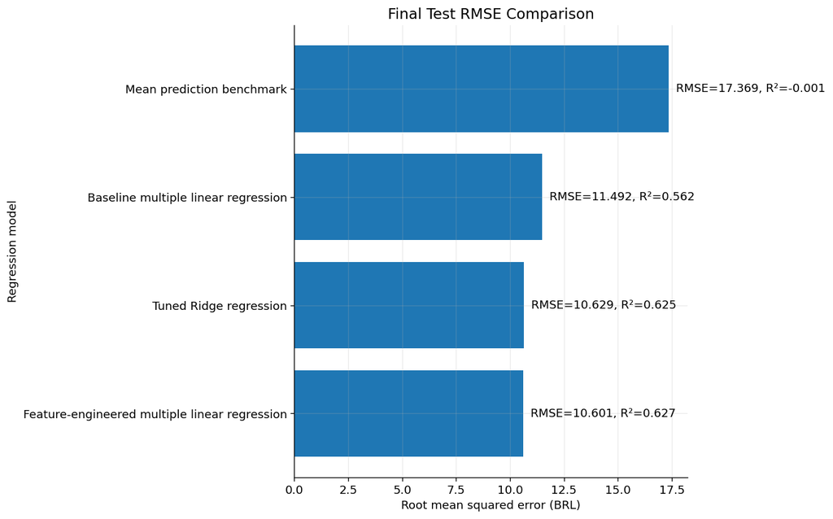

```python
# ============================================================
# FINAL MODEL RMSE COMPARISON
# ============================================================

figure, axis = plt.subplots(
    figsize=(11, 7)
)

axis.barh(
    final_model_comparison_df["model"],
    final_model_comparison_df["RMSE"]
)

axis.set_title(
    "Final Test RMSE Comparison"
)

axis.set_xlabel(
    "Root mean squared error (BRL)"
)

axis.set_ylabel(
    "Regression model"
)

for row_position, row in final_model_comparison_df.iterrows():

    axis.text(
        row["RMSE"],
        row_position,
        (
            f"  RMSE={row['RMSE']:.3f}, "
            f"R²={row['R_squared']:.3f}"
        ),
        va="center"
    )

plt.tight_layout()

save_current_figure(
    "19_final_model_rmse_comparison.png"
)

plt.show()
```

```python
# ============================================================
# FINAL RIDGE PREDICTION RESULTS
# ============================================================

final_ridge_results_df = (
    modelling_df
    .iloc[test_indices][
        [
            "order_id",
            "order_item_id",
            "freight_value",
            "price",
            "product_weight_g",
            "product_length_cm",
            "product_height_cm",
            "product_width_cm",
            "distance_km",
            "same_state",
            "product_category_name_english",
            "customer_state",
            "seller_state"
        ]
    ]
    .copy()
    .reset_index(drop=True)
)

final_ridge_results_df[
    "baseline_prediction"
] = baseline_predictions

final_ridge_results_df[
    "ridge_prediction"
] = ridge_test_predictions

final_ridge_results_df[
    "baseline_residual"
] = (
    final_ridge_results_df["freight_value"]
    - final_ridge_results_df["baseline_prediction"]
)

final_ridge_results_df[
    "ridge_residual"
] = (
    final_ridge_results_df["freight_value"]
    - final_ridge_results_df["ridge_prediction"]
)

final_ridge_results_df[
    "baseline_absolute_error"
] = (
    final_ridge_results_df[
        "baseline_residual"
    ].abs()
)

final_ridge_results_df[
    "ridge_absolute_error"
] = (
    final_ridge_results_df[
        "ridge_residual"
    ].abs()
)

final_ridge_results_df[
    "ridge_squared_error"
] = (
    final_ridge_results_df[
        "ridge_residual"
    ] ** 2
)

final_ridge_results_df[
    "error_reduction_from_baseline"
] = (
    final_ridge_results_df[
        "baseline_absolute_error"
    ]
    - final_ridge_results_df[
        "ridge_absolute_error"
    ]
)

final_ridge_results_df.head()
```

|  | order_id | order_item_id | freight_value | price | product_weight_g | product_length_cm | product_height_cm | product_width_cm | distance_km | same_state | product_category_name_english | customer_state | seller_state | baseline_prediction | ridge_prediction | baseline_residual | ridge_residual | baseline_absolute_error | ridge_absolute_error | ridge_squared_error | error_reduction_from_baseline |
| --- | --- | --- | --- | --- | --- | --- | --- | --- | --- | --- | --- | --- | --- | --- | --- | --- | --- | --- | --- | --- | --- |
| 0 | b124967afcc82ef17ec41020fe2a9136 | 1 | 8.880 | 49.990 | 7,875.000 | 60.000 | 25.000 | 25.000 | 27.022 | 1.000 | furniture_living_room | SP | SP | 24.429 | 17.902 | -15.549 | -9.022 | 15.549 | 9.022 | 81.396 | 6.527 |
| 1 | fd220bb11ef8a046fef08e7c51f11651 | 1 | 17.810 | 79.990 | 650.000 | 25.000 | 11.000 | 15.000 | 495.117 | 0.000 | computers_accessories | RJ | SP | 16.360 | 17.205 | 1.450 | 0.605 | 1.450 | 0.605 | 0.366 | 0.845 |
| 2 | 2b7d922e73fbd058099b6ff4b33e99f7 | 1 | 17.760 | 169.990 | 433.000 | 21.000 | 12.000 | 16.000 | 1,293.638 | 0.000 | watches_gifts | MT | SP | 23.835 | 21.894 | -6.075 | -4.134 | 6.075 | 4.134 | 17.091 | 1.941 |
| 3 | 709df04791b8bd393b34a58de3cf142d | 1 | 19.440 | 223.000 | 300.000 | 18.000 | 9.000 | 14.000 | 822.746 | 0.000 | watches_gifts | ES | SP | 18.627 | 19.166 | 0.813 | 0.274 | 0.813 | 0.274 | 0.075 | 0.538 |
| 4 | 166b01d0fce75a595b92ad9e84e0843b | 1 | 29.090 | 98.000 | 925.000 | 25.000 | 6.000 | 16.000 | 2,094.074 | 0.000 | health_beauty | CE | SP | 27.120 | 27.807 | 1.970 | 1.283 | 1.970 | 1.283 | 1.646 | 0.687 |

### 12.1 Final Residual Diagnostics

The final actual-versus-predicted and residual-versus-fitted plots are used to determine whether feature engineering and regularisation reduced systematic error.

Residuals above zero indicate underprediction, while residuals below zero indicate overprediction. A horizontal residual pattern centred around zero is preferable. Increasing spread at higher predictions would indicate that expensive shipments remain more difficult to estimate.

```
Figure saved to: /Users/zimmeljavedvirk/Desktop/datasciencemid/figures/20_ridge_actual_vs_predicted.png
```

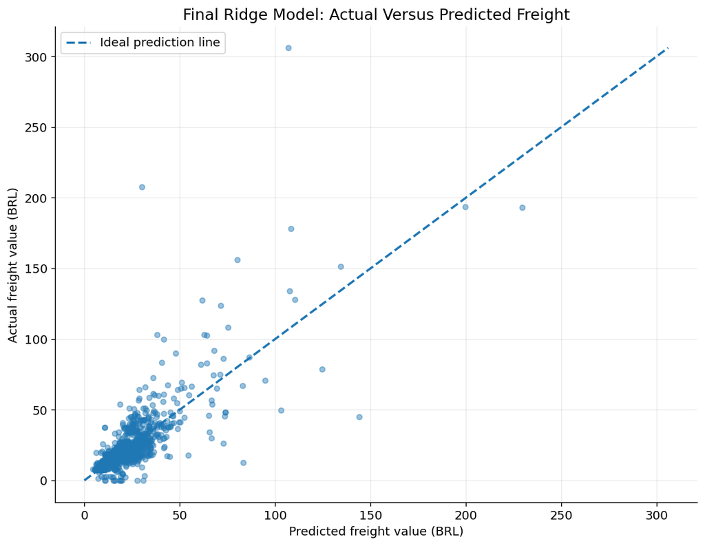

```python
# ============================================================
# FINAL RIDGE ACTUAL VERSUS PREDICTED
# ============================================================

minimum_ridge_plot_value = min(
    y_test.min(),
    ridge_test_predictions.min()
)

maximum_ridge_plot_value = max(
    y_test.max(),
    ridge_test_predictions.max()
)

figure, axis = plt.subplots(
    figsize=(9, 7)
)

axis.scatter(
    ridge_test_predictions,
    y_test,
    alpha=0.45,
    s=22
)

axis.plot(
    [
        minimum_ridge_plot_value,
        maximum_ridge_plot_value
    ],
    [
        minimum_ridge_plot_value,
        maximum_ridge_plot_value
    ],
    linestyle="--",
    linewidth=2,
    label="Ideal prediction line"
)

axis.set_title(
    "Final Ridge Model: Actual Versus Predicted Freight"
)

axis.set_xlabel(
    "Predicted freight value (BRL)"
)

axis.set_ylabel(
    "Actual freight value (BRL)"
)

axis.legend()

plt.tight_layout()

save_current_figure(
    "20_ridge_actual_vs_predicted.png"
)

plt.show()
```

```
Figure saved to: /Users/zimmeljavedvirk/Desktop/datasciencemid/figures/21_ridge_residuals_vs_fitted.png
```

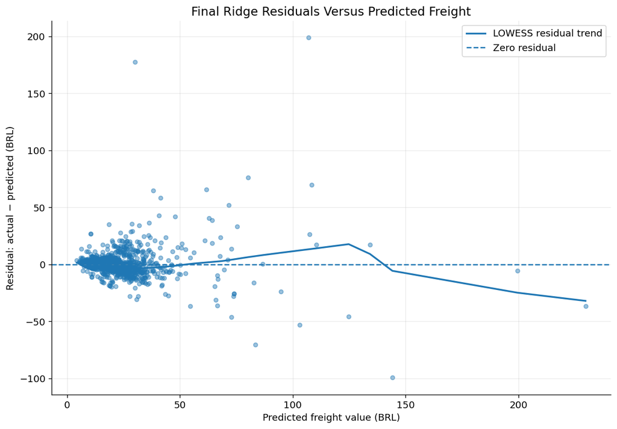

```python
# ============================================================
# FINAL RIDGE RESIDUALS VERSUS FITTED VALUES
# ============================================================

ridge_residuals = (
    y_test.to_numpy()
    - ridge_test_predictions
)

ridge_residual_lowess = lowess(
    endog=ridge_residuals,
    exog=ridge_test_predictions,
    frac=0.30,
    return_sorted=True
)

figure, axis = plt.subplots(
    figsize=(10, 7)
)

axis.scatter(
    ridge_test_predictions,
    ridge_residuals,
    alpha=0.45,
    s=22
)

axis.plot(
    ridge_residual_lowess[:, 0],
    ridge_residual_lowess[:, 1],
    linewidth=2,
    label="LOWESS residual trend"
)

axis.axhline(
    y=0,
    linestyle="--",
    linewidth=1.5,
    label="Zero residual"
)

axis.set_title(
    "Final Ridge Residuals Versus Predicted Freight"
)

axis.set_xlabel(
    "Predicted freight value (BRL)"
)

axis.set_ylabel(
    "Residual: actual − predicted (BRL)"
)

axis.legend()

plt.tight_layout()

save_current_figure(
    "21_ridge_residuals_vs_fitted.png"
)

plt.show()
```

```python
# ============================================================
# BASELINE AND RIDGE RESIDUAL COMPARISON
# ============================================================

final_residual_comparison_df = pd.DataFrame(
    [
        create_residual_summary(
            testing_residuals,
            "Baseline multiple linear regression"
        ),
        create_residual_summary(
            ridge_residuals,
            "Tuned Ridge regression"
        )
    ]
)

final_residual_comparison_df
```

|  | dataset | count | mean_residual | median_residual | standard_deviation | minimum | first_quartile | third_quartile | maximum | skewness | excess_kurtosis | mean_absolute_residual | percentage_within_5_brl | percentage_within_10_brl |
| --- | --- | --- | --- | --- | --- | --- | --- | --- | --- | --- | --- | --- | --- | --- |
| 0 | Baseline multiple linear regression | 1801 | 0.145 | -0.183 | 11.494 | -40.698 | -3.138 | 2.189 | 229.903 | 8.228 | 129.884 | 5.166 | 72.404 | 87.896 |
| 1 | Tuned Ridge regression | 1801 | -0.047 | -0.560 | 10.632 | -99.238 | -2.832 | 1.772 | 198.998 | 6.455 | 122.068 | 4.740 | 75.458 | 88.451 |

### 12.2 Group-Bootstrap Confidence Intervals

Ordinary row-level bootstrapping would incorrectly treat every order item as independent. Instead, complete order groups are sampled with replacement.

This produces confidence intervals that respect the grouped structure used during model training and validation. The same bootstrap samples are applied to the baseline and Ridge predictions, allowing a paired comparison of their prediction errors.

```python
# ============================================================
# ORDER-LEVEL CLUSTER BOOTSTRAP
# ============================================================

def perform_group_bootstrap(
    actual_values,
    baseline_prediction_values,
    ridge_prediction_values,
    group_values,
    number_of_iterations=1_000,
    random_state=42
):
    """
    Estimate group-bootstrap confidence intervals for model
    performance and paired improvement.

    Complete order groups are sampled with replacement.
    """

    actual_array = np.asarray(
        actual_values,
        dtype=float
    )

    baseline_array = np.asarray(
        baseline_prediction_values,
        dtype=float
    )

    ridge_array = np.asarray(
        ridge_prediction_values,
        dtype=float
    )

    group_array = np.asarray(
        group_values
    )

    unique_groups = np.unique(
        group_array
    )

    group_position_mapping = {
        group_value: np.flatnonzero(
            group_array == group_value
        )
        for group_value in unique_groups
    }

    random_generator = np.random.default_rng(
        random_state
    )

    bootstrap_records = []

    for bootstrap_iteration in range(
        number_of_iterations
    ):

        sampled_groups = random_generator.choice(
            unique_groups,
            size=len(unique_groups),
            replace=True
        )

        sampled_positions = np.concatenate(
            [
                group_position_mapping[
                    group_value
                ]
                for group_value in sampled_groups
            ]
        )

        sampled_actual = actual_array[
            sampled_positions
        ]

        sampled_baseline = baseline_array[
            sampled_positions
        ]

        sampled_ridge = ridge_array[
            sampled_positions
        ]

        baseline_rmse = calculate_rmse(
            sampled_actual,
            sampled_baseline
        )

        ridge_rmse = calculate_rmse(
            sampled_actual,
            sampled_ridge
        )

        baseline_mae = mean_absolute_error(
            sampled_actual,
            sampled_baseline
        )

        ridge_mae = mean_absolute_error(
            sampled_actual,
            sampled_ridge
        )

        ridge_r_squared = r2_score(
            sampled_actual,
            sampled_ridge
        )

        bootstrap_records.append(
            {
                "bootstrap_iteration":
                    bootstrap_iteration + 1,
                "baseline_RMSE":
                    baseline_rmse,
                "ridge_RMSE":
                    ridge_rmse,
                "RMSE_reduction":
                    baseline_rmse
                    - ridge_rmse,
                "baseline_MAE":
                    baseline_mae,
                "ridge_MAE":
                    ridge_mae,
                "MAE_reduction":
                    baseline_mae
                    - ridge_mae,
                "ridge_R_squared":
                    ridge_r_squared
            }
        )

    return pd.DataFrame(
        bootstrap_records
    )


group_bootstrap_results_df = (
    perform_group_bootstrap(
        actual_values=y_test.to_numpy(),
        baseline_prediction_values=
            baseline_predictions,
        ridge_prediction_values=
            ridge_test_predictions,
        group_values=
            groups_test.to_numpy(),
        number_of_iterations=1_000,
        random_state=RANDOM_STATE
    )
)

group_bootstrap_results_df.head()
```

|  | bootstrap_iteration | baseline_RMSE | ridge_RMSE | RMSE_reduction | baseline_MAE | ridge_MAE | MAE_reduction | ridge_R_squared |
| --- | --- | --- | --- | --- | --- | --- | --- | --- |
| 0 | 1 | 10.034 | 9.658 | 0.376 | 4.893 | 4.562 | 0.331 | 0.593 |
| 1 | 2 | 12.760 | 11.676 | 1.083 | 5.394 | 4.829 | 0.565 | 0.619 |
| 2 | 3 | 8.854 | 8.469 | 0.385 | 4.848 | 4.497 | 0.351 | 0.687 |
| 3 | 4 | 10.259 | 9.117 | 1.142 | 4.760 | 4.234 | 0.526 | 0.651 |
| 4 | 5 | 11.170 | 10.066 | 1.103 | 5.052 | 4.496 | 0.556 | 0.624 |

```python
# ============================================================
# GROUP-BOOTSTRAP CONFIDENCE INTERVAL SUMMARY
# ============================================================

def bootstrap_confidence_interval(
    values,
    confidence_level=0.95
):
    """
    Return the bootstrap mean and percentile confidence interval.
    """

    lower_percentile = (
        (1 - confidence_level)
        / 2
        * 100
    )

    upper_percentile = (
        100 - lower_percentile
    )

    values = pd.Series(
        values
    ).dropna()

    return {
        "mean": values.mean(),
        "lower_confidence_limit": (
            np.percentile(
                values,
                lower_percentile
            )
        ),
        "upper_confidence_limit": (
            np.percentile(
                values,
                upper_percentile
            )
        )
    }


bootstrap_metrics = {
    "Ridge RMSE":
        group_bootstrap_results_df[
            "ridge_RMSE"
        ],
    "Ridge MAE":
        group_bootstrap_results_df[
            "ridge_MAE"
        ],
    "Ridge R²":
        group_bootstrap_results_df[
            "ridge_R_squared"
        ],
    "RMSE reduction from baseline":
        group_bootstrap_results_df[
            "RMSE_reduction"
        ],
    "MAE reduction from baseline":
        group_bootstrap_results_df[
            "MAE_reduction"
        ]
}


bootstrap_confidence_records = []

for metric_name, metric_values in (
    bootstrap_metrics.items()
):

    confidence_results = (
        bootstrap_confidence_interval(
            metric_values,
            confidence_level=0.95
        )
    )

    bootstrap_confidence_records.append(
        {
            "metric": metric_name,
            "bootstrap_mean":
                confidence_results["mean"],
            "95_percent_lower_limit":
                confidence_results[
                    "lower_confidence_limit"
                ],
            "95_percent_upper_limit":
                confidence_results[
                    "upper_confidence_limit"
                ]
        }
    )


bootstrap_confidence_interval_df = (
    pd.DataFrame(
        bootstrap_confidence_records
    )
)

bootstrap_confidence_interval_df
```

|  | metric | bootstrap_mean | 95_percent_lower_limit | 95_percent_upper_limit |
| --- | --- | --- | --- | --- |
| 0 | Ridge RMSE | 10.485 | 8.002 | 13.241 |
| 1 | Ridge MAE | 4.733 | 4.302 | 5.212 |
| 2 | Ridge R² | 0.629 | 0.514 | 0.738 |
| 3 | RMSE reduction from baseline | 0.876 | -0.099 | 1.814 |
| 4 | MAE reduction from baseline | 0.430 | 0.223 | 0.633 |

```python
# ============================================================
# BOOTSTRAP EVIDENCE OF RIDGE IMPROVEMENT
# ============================================================

ridge_rmse_improvement_probability = (
    group_bootstrap_results_df[
        "RMSE_reduction"
    ] > 0
).mean()

ridge_mae_improvement_probability = (
    group_bootstrap_results_df[
        "MAE_reduction"
    ] > 0
).mean()

paired_bootstrap_conclusion_df = pd.DataFrame(
    {
        "measurement": [
            (
                "Proportion of bootstrap samples "
                "where Ridge reduced RMSE"
            ),
            (
                "Proportion of bootstrap samples "
                "where Ridge reduced MAE"
            ),
            (
                "Median bootstrap RMSE reduction"
            ),
            (
                "Median bootstrap MAE reduction"
            )
        ],
        "value": [
            ridge_rmse_improvement_probability,
            ridge_mae_improvement_probability,
            group_bootstrap_results_df[
                "RMSE_reduction"
            ].median(),
            group_bootstrap_results_df[
                "MAE_reduction"
            ].median()
        ]
    }
)

paired_bootstrap_conclusion_df
```

|  | measurement | value |
| --- | --- | --- |
| 0 | Proportion of bootstrap samples where Ridge re... | 0.964 |
| 1 | Proportion of bootstrap samples where Ridge re... | 1.000 |
| 2 | Median bootstrap RMSE reduction | 0.901 |
| 3 | Median bootstrap MAE reduction | 0.427 |

### 12.3 Error Analysis Across Freight-Cost Bands

Overall metrics can hide poor performance for unusual or expensive deliveries. Test observations are therefore divided into quartiles using their actual freight values.

This analysis determines whether the final model performs consistently across low-, medium- and high-cost shipments.

```python
# ============================================================
# PERFORMANCE BY ACTUAL FREIGHT QUARTILE
# ============================================================

final_ridge_results_df[
    "actual_freight_quartile"
] = pd.qcut(
    final_ridge_results_df[
        "freight_value"
    ],
    q=4,
    labels=[
        "Q1: Lowest freight",
        "Q2: Lower-middle freight",
        "Q3: Upper-middle freight",
        "Q4: Highest freight"
    ],
    duplicates="drop"
)


def summarise_prediction_performance(
    dataframe,
    grouping_column,
    actual_column="freight_value",
    prediction_column="ridge_prediction"
):
    """
    Calculate model performance within each subgroup.
    """

    performance_records = []

    for (
        group_name,
        group_dataframe
    ) in dataframe.groupby(
        grouping_column,
        observed=True,
        dropna=False
    ):

        actual_values = group_dataframe[
            actual_column
        ]

        predicted_values = group_dataframe[
            prediction_column
        ]

        performance_records.append(
            {
                "group": str(group_name),
                "observation_count":
                    len(group_dataframe),
                "mean_actual_freight":
                    actual_values.mean(),
                "mean_predicted_freight":
                    predicted_values.mean(),
                "mean_residual": (
                    actual_values
                    - predicted_values
                ).mean(),
                "MAE": mean_absolute_error(
                    actual_values,
                    predicted_values
                ),
                "RMSE": calculate_rmse(
                    actual_values,
                    predicted_values
                ),
                "R_squared": (
                    r2_score(
                        actual_values,
                        predicted_values
                    )
                    if actual_values.nunique() > 1
                    else np.nan
                )
            }
        )

    return pd.DataFrame(
        performance_records
    )


freight_quartile_performance_df = (
    summarise_prediction_performance(
        dataframe=final_ridge_results_df,
        grouping_column=
            "actual_freight_quartile"
    )
)

freight_quartile_performance_df
```

|  | group | observation_count | mean_actual_freight | mean_predicted_freight | mean_residual | MAE | RMSE | R_squared |
| --- | --- | --- | --- | --- | --- | --- | --- | --- |
| 0 | Q1: Lowest freight | 451 | 9.485 | 11.101 | -1.617 | 2.784 | 5.893 | -3.865 |
| 1 | Q2: Lower-middle freight | 450 | 14.866 | 16.304 | -1.437 | 2.351 | 3.415 | -12.271 |
| 2 | Q3: Upper-middle freight | 451 | 18.426 | 20.193 | -1.766 | 3.710 | 5.316 | -20.390 |
| 3 | Q4: Highest freight | 449 | 37.672 | 33.022 | 4.651 | 10.132 | 19.447 | 0.494 |

The negative R² values within some freight-cost quartiles do not mean that the complete Ridge model performs worse than the overall benchmark. Dividing test observations according to the actual target creates groups with a deliberately restricted range of freight values. Because R² depends on the amount of target variation within a group, it becomes unstable and less informative inside these narrow freight bands. RMSE, MAE and mean residual are therefore treated as the principal measures for subgroup performance.

```
Figure saved to: /Users/zimmeljavedvirk/Desktop/datasciencemid/figures/22_ridge_rmse_by_freight_quartile.png
```

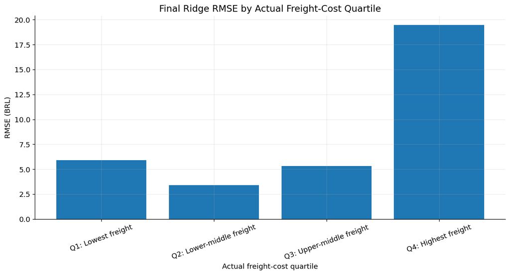

```python
# ============================================================
# RIDGE RMSE BY ACTUAL FREIGHT QUARTILE
# ============================================================

figure, axis = plt.subplots(
    figsize=(11, 6)
)

axis.bar(
    freight_quartile_performance_df[
        "group"
    ],
    freight_quartile_performance_df[
        "RMSE"
    ]
)

axis.set_title(
    "Final Ridge RMSE by Actual Freight-Cost Quartile"
)

axis.set_xlabel(
    "Actual freight-cost quartile"
)

axis.set_ylabel(
    "RMSE (BRL)"
)

axis.tick_params(
    axis="x",
    rotation=20
)

plt.tight_layout()

save_current_figure(
    "22_ridge_rmse_by_freight_quartile.png"
)

plt.show()
```

```python
# ============================================================
# PERFORMANCE BY DISTANCE QUARTILE
# ============================================================

final_ridge_results_df[
    "distance_quartile"
] = pd.qcut(
    final_ridge_results_df[
        "distance_km"
    ],
    q=4,
    labels=[
        "Q1: Shortest distance",
        "Q2: Lower-middle distance",
        "Q3: Upper-middle distance",
        "Q4: Longest distance"
    ],
    duplicates="drop"
)

distance_quartile_performance_df = (
    summarise_prediction_performance(
        dataframe=final_ridge_results_df,
        grouping_column="distance_quartile"
    )
)

distance_quartile_performance_df
```

|  | group | observation_count | mean_actual_freight | mean_predicted_freight | mean_residual | MAE | RMSE | R_squared |
| --- | --- | --- | --- | --- | --- | --- | --- | --- |
| 0 | Q1: Shortest distance | 451 | 12.867 | 13.011 | -0.144 | 3.005 | 6.037 | 0.515 |
| 1 | Q2: Lower-middle distance | 450 | 19.047 | 17.831 | 1.217 | 4.392 | 14.052 | 0.444 |
| 2 | Q3: Upper-middle distance | 450 | 19.922 | 20.956 | -1.034 | 4.213 | 7.654 | 0.669 |
| 3 | Q4: Longest distance | 450 | 28.562 | 28.788 | -0.226 | 7.352 | 12.632 | 0.663 |

```python
# ============================================================
# PERFORMANCE FOR SAME-STATE AND INTERSTATE DELIVERIES
# ============================================================

final_ridge_results_df[
    "route_type"
] = final_ridge_results_df[
    "same_state"
].map(
    {
        1: "Same-state delivery",
        0: "Interstate delivery"
    }
).fillna(
    "Unknown route type"
)

route_performance_df = (
    summarise_prediction_performance(
        dataframe=final_ridge_results_df,
        grouping_column="route_type"
    )
)

route_performance_df
```

|  | group | observation_count | mean_actual_freight | mean_predicted_freight | mean_residual | MAE | RMSE | R_squared |
| --- | --- | --- | --- | --- | --- | --- | --- | --- |
| 0 | Interstate delivery | 1151 | 23.821 | 23.845 | -0.024 | 5.739 | 12.585 | 0.600 |
| 1 | Same-state delivery | 650 | 13.499 | 13.586 | -0.087 | 2.969 | 5.706 | 0.502 |

```python
# ============================================================
# PERFORMANCE BY PRODUCT-WEIGHT QUARTILE
# ============================================================

weight_available_mask = (
    final_ridge_results_df[
        "product_weight_g"
    ].notna()
)

weight_performance_source_df = (
    final_ridge_results_df.loc[
        weight_available_mask
    ].copy()
)

weight_performance_source_df[
    "weight_quartile"
] = pd.qcut(
    weight_performance_source_df[
        "product_weight_g"
    ],
    q=4,
    labels=[
        "Q1: Lightest products",
        "Q2: Lower-middle weight",
        "Q3: Upper-middle weight",
        "Q4: Heaviest products"
    ],
    duplicates="drop"
)

weight_quartile_performance_df = (
    summarise_prediction_performance(
        dataframe=
            weight_performance_source_df,
        grouping_column="weight_quartile"
    )
)

weight_quartile_performance_df
```

|  | group | observation_count | mean_actual_freight | mean_predicted_freight | mean_residual | MAE | RMSE | R_squared |
| --- | --- | --- | --- | --- | --- | --- | --- | --- |
| 0 | Q1: Lightest products | 451 | 14.911 | 14.557 | 0.354 | 2.645 | 4.263 | 0.568 |
| 1 | Q2: Lower-middle weight | 473 | 15.754 | 15.731 | 0.023 | 2.749 | 4.648 | 0.574 |
| 2 | Q3: Upper-middle weight | 430 | 17.865 | 18.729 | -0.864 | 3.862 | 7.080 | 0.303 |
| 3 | Q4: Heaviest products | 447 | 32.068 | 31.806 | 0.261 | 9.804 | 19.125 | 0.572 |

```python
# ============================================================
# FINAL SELECTED MODEL SUMMARY
# ============================================================

final_selected_model_summary_df = pd.DataFrame(
    {
        "measurement": [
            "Selected model",
            "Selected Ridge alpha",
            "Test RMSE",
            "Test MAE",
            "Test median absolute error",
            "Test R²",
            "Mean group CV RMSE",
            "Group CV RMSE standard deviation",
            "Mean group CV MAE",
            "Mean group CV R²",
            "RMSE improvement over baseline",
            "MAE improvement over baseline",
            "Number of transformed features",
            "Training observations",
            "Testing observations",
            "Overlapping train-test orders"
        ],
        "value": [
            "Feature-engineered Ridge regression",
            best_ridge_model.alpha,
            ridge_test_metrics["RMSE"],
            ridge_test_metrics["MAE"],
            ridge_test_metrics[
                "median_absolute_error"
            ],
            ridge_test_metrics["R_squared"],
            ridge_cv_fold_results_df[
                "RMSE"
            ].mean(),
            ridge_cv_fold_results_df[
                "RMSE"
            ].std(ddof=1),
            ridge_cv_fold_results_df[
                "MAE"
            ].mean(),
            ridge_cv_fold_results_df[
                "R_squared"
            ].mean(),
            (
                baseline_metrics["RMSE"]
                - ridge_test_metrics["RMSE"]
            ),
            (
                baseline_metrics["MAE"]
                - ridge_test_metrics["MAE"]
            ),
            len(ridge_feature_names),
            len(X_train),
            len(X_test),
            len(overlapping_orders)
        ]
    }
)

final_selected_model_summary_df
```

|  | measurement | value |
| --- | --- | --- |
| 0 | Selected model | Feature-engineered Ridge regression |
| 1 | Selected Ridge alpha | 300.000 |
| 2 | Test RMSE | 10.629 |
| 3 | Test MAE | 4.740 |
| 4 | Test median absolute error | 2.289 |
| 5 | Test R² | 0.625 |
| 6 | Mean group CV RMSE | 8.746 |
| 7 | Group CV RMSE standard deviation | 0.330 |
| 8 | Mean group CV MAE | 4.484 |
| 9 | Mean group CV R² | 0.609 |
| 10 | RMSE improvement over baseline | 0.863 |
| 11 | MAE improvement over baseline | 0.427 |
| 12 | Number of transformed features | 131 |
| 13 | Training observations | 7199 |
| 14 | Testing observations | 1801 |
| 15 | Overlapping train-test orders | 0 |

```python
# ============================================================
# SAVE FINAL EVALUATION OUTPUTS
# ============================================================

final_model_comparison_df.to_csv(
    PROCESSED_DATA_DIRECTORY
    / "final_model_comparison.csv",
    index=False
)

final_ridge_results_df.to_csv(
    PROCESSED_DATA_DIRECTORY
    / "final_ridge_test_results.csv",
    index=False
)

final_residual_comparison_df.to_csv(
    PROCESSED_DATA_DIRECTORY
    / "final_residual_comparison.csv",
    index=False
)

group_bootstrap_results_df.to_csv(
    PROCESSED_DATA_DIRECTORY
    / "group_bootstrap_results.csv",
    index=False
)

bootstrap_confidence_interval_df.to_csv(
    PROCESSED_DATA_DIRECTORY
    / "bootstrap_confidence_intervals.csv",
    index=False
)

paired_bootstrap_conclusion_df.to_csv(
    PROCESSED_DATA_DIRECTORY
    / "paired_bootstrap_conclusions.csv",
    index=False
)

freight_quartile_performance_df.to_csv(
    PROCESSED_DATA_DIRECTORY
    / "freight_quartile_performance.csv",
    index=False
)

distance_quartile_performance_df.to_csv(
    PROCESSED_DATA_DIRECTORY
    / "distance_quartile_performance.csv",
    index=False
)

route_performance_df.to_csv(
    PROCESSED_DATA_DIRECTORY
    / "route_performance.csv",
    index=False
)

weight_quartile_performance_df.to_csv(
    PROCESSED_DATA_DIRECTORY
    / "weight_quartile_performance.csv",
    index=False
)

final_selected_model_summary_df.to_csv(
    PROCESSED_DATA_DIRECTORY
    / "final_selected_model_summary.csv",
    index=False
)

print(
    "Final model-evaluation outputs saved successfully."
)
```

```
Final model-evaluation outputs saved successfully.
```

## Programming Style and Reproducibility

The notebook follows a consistent and reproducible programming structure. Variables and functions use descriptive names, repeated operations are implemented through reusable functions and major processing stages are documented using comments and Markdown explanations. Configuration values, including the random state, sample size, test proportion and number of cross-validation folds, are defined centrally rather than repeatedly entered as unnamed constants.

Raw datasets are preserved separately from cleaned working copies, while processed datasets, audit tables and figures are stored in dedicated output directories. Assertions and merge-validation arguments are used to detect duplicate keys, unexpected row multiplication, missing targets and train-test group overlap. Scikit-learn pipelines ensure that imputation, scaling and categorical encoding are fitted using training data only. A fixed random state supports reproducible sampling, splitting and bootstrap analysis.

## 13. Evaluation of the Model and Project

Three regression approaches were evaluated: baseline multiple linear regression, feature-engineered ordinary least-squares regression and tuned Ridge regression. Performance was assessed using RMSE, MAE and R². RMSE was selected as the primary measure because it expresses prediction error in BRL and penalises large errors more heavily. This is appropriate for freight-cost estimation, where a substantial underprediction may create greater financial risk than several small errors. MAE was also reported because it provides an easily interpretable average error, while R² indicates the proportion of freight-cost variation explained by the model.

The baseline model achieved an RMSE of 11.492 BRL, an MAE of 5.166 BRL and an R² of 0.562. It provided a transparent benchmark and confirmed that product, geographical and order-level variables contain useful predictive information. However, its higher errors and structured residual patterns showed that simple additive relationships could not fully capture unusually heavy, bulky or long-distance deliveries.

Feature-engineered ordinary least squares improved RMSE to 10.601 BRL, MAE to 4.755 BRL and R² to 0.627. It achieved the lowest RMSE and highest R², demonstrating that parcel volume, logarithmic transformations, squared terms and distance interactions captured important non-linear freight relationships. Nevertheless, several engineered predictors represented correlated transformations of the same underlying variables, which may reduce coefficient stability and make interpretation less reliable.

The tuned Ridge model achieved an RMSE of 10.629 BRL, an MAE of 4.740 BRL and an R² of 0.625. Although its RMSE was 0.028 BRL higher than engineered ordinary least squares, Ridge achieved the lowest MAE, the lowest median absolute error and stronger group-aware cross-validation performance. It was therefore selected as the preferred model because regularisation provides a better overall balance between predictive accuracy, coefficient stability and generalisation.

Bootstrap analysis showed that Ridge reduced RMSE relative to the baseline in 96.4% of order-level samples and reduced MAE in every sample. However, performance remained weaker for expensive deliveries: in the highest freight quartile, RMSE increased to 19.447 BRL and average underprediction was 4.651 BRL. The model should therefore support preliminary quotations, budgeting and identification of high-risk orders rather than fully automated pricing.

The project contributes to e-commerce logistics by providing an interpretable and reproducible freight-cost estimation workflow. It is transferable to courier pricing, last-mile delivery planning, warehouse cost estimation and supply-chain budgeting, but each application would require local validation, relevant operational variables and periodic retraining.

## References

Boysen, N., Fedtke, S. and Schwerdfeger, S. (2021) ‘Last-mile delivery concepts: a survey from an operational research perspective’, *OR Spectrum*, 43, pp. 1–58. Available at: https://doi.org/10.1007/s00291-020-00607-8

Breusch, T.S. and Pagan, A.R. (1979) ‘A simple test for heteroscedasticity and random coefficient variation’, *Econometrica*, 47(5), pp. 1287–1294. Available at: https://doi.org/10.2307/1911963

Cook, R.D. (1977) ‘Detection of influential observation in linear regression’, *Technometrics*, 19(1), pp. 15–18. Available at: https://doi.org/10.1080/00401706.1977.10489493

Gevaers, R., Van de Voorde, E. and Vanelslander, T. (2014) ‘Cost modelling and simulation of last-mile characteristics in an innovative B2C supply chain environment with implications on urban areas and cities’, *Procedia – Social and Behavioral Sciences*, 125, pp. 398–411. Available at: https://doi.org/10.1016/j.sbspro.2014.01.1483

Ghasemi, A. and Zahediasl, S. (2012) ‘Normality tests for statistical analysis: a guide for non-statisticians’, *International Journal of Endocrinology and Metabolism*, 10(2), pp. 486–489. Available at: https://doi.org/10.5812/ijem.3505

Iglewicz, B. and Hoaglin, D.C. (1993) *How to Detect and Handle Outliers*. Milwaukee, WI: ASQC Quality Press. Available at: https://books.google.com/books?id=siInAQAAIAAJ

James, G., Witten, D., Hastie, T., Tibshirani, R. and Taylor, J. (2023) *An Introduction to Statistical Learning: with Applications in Python*. Cham: Springer. Available at: https://doi.org/10.1007/978-3-031-38747-0

Kapoor, S. and Narayanan, A. (2023) ‘Leakage and the reproducibility crisis in machine-learning-based science’, *Patterns*, 4(9), article 100804. Available at: https://doi.org/10.1016/j.patter.2023.100804

Lim, S.F.W.T., Jin, X. and Srai, J.S. (2018) ‘Consumer-driven e-commerce: a literature review, design framework, and research agenda on last-mile logistics models’, *International Journal of Physical Distribution & Logistics Management*, 48(3), pp. 308–332. Available at: https://doi.org/10.1108/IJPDLM-02-2017-0081

Olist (n.d.) *Brazilian E-Commerce Public Dataset by Olist*. Kaggle. Available at: https://www.kaggle.com/datasets/olistbr/brazilian-ecommerce

Schober, P., Boer, C. and Schwarte, L.A. (2018) ‘Correlation coefficients: appropriate use and interpretation’, *Anesthesia & Analgesia*, 126(5), pp. 1763–1768. Available at: https://doi.org/10.1213/ANE.0000000000002864

Scikit-learn Developers (n.d.-b) ‘GroupKFold’, *Scikit-learn documentation*. Available at: https://scikit-learn.org/stable/modules/generated/sklearn.model_selection.GroupKFold.html

Sinnott, R.W. (1984) ‘Virtues of the Haversine’, *Sky & Telescope*, 68(2), pp. 158–159. Available at: https://ui.adsabs.harvard.edu/abs/1984S%26T....68R.158S

Tukey, J.W. (1977) *Exploratory Data Analysis*. Reading, MA: Addison-Wesley. Available at: https://books.google.com/books?id=UT9dAAAAIAAJ